# 3.Bootstrap

NikolayNikolaev

2023-10-25

# 2. Metodidi ricampionamento

## 2.1. Introduzione:

Classical inference was developed in the parametric context, when resources computational resources were absent or limited, and is based on mathematical analysis (exact). The term resampling refers to production and use of randomized versions of the available sample { indicated below with the term sample { obtained by re-extracting the values from the original sample. Resampling methods have been relatively developed recent as a result of the advancement of information technologies and the increase of computational power.

The inference is called parametric if it is based on the assumption that the v.c. $X$ from from which the sample comes has a probability law of $F(x)$ or a density function a note, i.e. the functional form or family is specified parametric to which it belongs.

In the context of non-parametric inference, a functional form is not assumed note for $F(x)$ because it is risky or unrealistic due to the lack of there is insufficient a priori information, or the estimator has a complex structure to prevent the use of exact analytical methods to derive the law of density or probability. Traditional inference offers, what solution to problems illustrated previously problems, the asymptotic tool or analytical results that are valid for infinite sample size.

The methods resampling methods are mainly used in the non-parametric context, where this and the methods of traditional inference cannot be correctly applied.

This in practice - where the samples are obviously finite - translates into approximate solutions whose precision is arbitrary because it depends on a sort of empirical hypothesis, i.e. $n$ sufficiently large.

Resampling methods represent a valid alternative to use of asymptotic approximations.

They can be used if available of adequate computational power, and for this reason they are called computer based methods. They provide approximate solutions because they are based on (stochastic) simulations.

## 2.2. Resampling

In the non-parametric contexts described above, the only known information is represented by the sample and all that can be done is, so to speak, “to let the data speak as much as possible”, extrapolating from them and only from them , all information about the parameter $\nu$.

In particular, resampling methods are based on the following logic: in the absence of a priori information that allow us to formulate hypotheses about $F(x)$, are exploited intensively data through iterated sample reuse.

All methods are also classified under the term resampling methods modern methods aimed at evaluating and/or improving the accuracy of an estimator, typically complex. For example, statistics are often used complex for which it is not possible to obtain the analytical form for the error standard.

The dispersion of the sampling distribution called the standard error and described by the standard deviation. The standard error of $\bar{X}$ describes how much $\bar{x}$ is variable from sample to sample of the same size $n$. TThe term standard error distinguishes this measurement from the standard deviation $\sigma$ referring instead to the population.

Resampling typically occurs to the computer and can be understood as the simulation of the sample space through the computer production of a subset, precisely the one allowed by the original sample.

The evaluation of accuracy is a fundamental phase of the inference process: once you get the $\nu$ estimate for the $\nu$ parameter through the data samples in accordance with statistical principles and it is necessary to establish their accuracy through the evaluation of some characteristic of the correspondent estimator $\hat{\Theta}$ . Among these, the evaluation of the distortion:

$$Dixtr(\hat{\Theta})= E(\hat{\Theta}) -
\nu$$

with the aim of correcting it, and the estimate of the dispersion of the estimator around to the object of the estimate, that is, its mean squared error error, MSE):

$$MSE(\hat{\Theta})= E[\hat{\Theta} -
\nu]^2 = V[\hat{\Theta}] + Dist(\hat{\theta})^2$$
or, in the case of an unbiased estimator, its variance:

$Var[\hat{\Theta}]= E[\hat{|theta} - E(\hat{\Theta})]^2$

This allows us to proceed with the inference with the construction of intervals of con dence and the testing of hypotheses on the parameter $\nu$

## 2.3. The Bootstrap

The bootstrap represents a computational resampling method that treats the sample distribution as if it were the true distribution of population and approximates the characteristics of the sampling distribution unknown by simulation. It is the best known of the modern methods computer based statistics created by Brad Efron in 1977. Efron in 2018 and was awarded the International Prize in Statistics1. The motivation uttered by Sir David Cox and the following: *Because the bootstrap is easy for a computer to calculate and is applicable in an exceptionally wide range of situations, the method has found use in many fields of science, technology, medicine and public a airs*.

On that occasion Prof. Efron also told the following anecdote: *I remember when going into stati- stics that the rst year I thought that this will be pretty easy since I’ve dealt with it with math and that’s supposed to be hard. But statistics was much harder for me at the beginning than any other age. It took years before I felt really Comfortable.*

Davison and Hinkley (1997) published the first article by Efron on the bootstrap method (which was initially rejected by the magazine) It was one of the central events for statistics, both because it synthesized some of the original ideas about sampling was because it laid the foundation for a new area of simulation-based statistical analysis.

The name bootstrap, assigned to the method by Efron himself and inspired by character Baron Munchausen from a popular story that this young man had fallen into a lake and, not knowing how to swim, he was trying to get out from the water *by clinging to the laces of their boots*.

This method developed due to its simplicity combined with availability a of growing computing power that is increasingly less expensive. In the lasts years, has experienced rapid and extensive development, so much so that today it and applied in the most varied areas of statistics: as well as in inference in general, also in regression models, in time series analysis, in sample theory, biometric applications and much more.

We will see here the fundamentals of the Bootstrap method as it originally existed proposed. We therefore place ourselves in the usual inferential context nonparametric, and the following notation is used:

- $X$ - the random variable interpreter of the character on which one intends to make an inference,
- $F(x)$ - his *cdf*, completely unknown,
- $\nu$ - the object of the estimate,
- it is assumed that $\nu$ can be expressed as a function of the unknown $F$ equals a to say $\nu=\nu(F)$

Example: - $\nu = Median(X)= x_{0.5}$ is a function of F according to the relation $x_{0.5} = F^{-1}(0.5) = inf[x|F(x) \geq 0.5]; \nu=E(X)$ is a dunction of $F$ according to relation $E(X) = \int_{\mathcal{R}} x.\varphi(x)dx = \int_{\mathcal{R} xfF(x)}$

- where $\varphi(x)$ os cdf or (!!! - f.p) of $X$ and so on.

The logic on which Boostrap is based is the fusion of two techniques: - the plug-in principle, known also as the substitution principle, - the Monte Carlo approximation, which determines the use of simulations to the calculator.

At the basis of the plug-in principle is the notion of an empirical distribution function $\hat{F_n}$, already referred to in the previous chapter during the introduction of the Kolmogorov-Smirnov test. According to the plug-in principle the estimate for $\nu=\nu(F)$ is constructed by substituting (plugging in) the distribution function for the unknown $F$ empirical that is: $\hat{\nu}=\nu(\hat{F_})$.

The sample mean, of which they are known the many formal properties which estimate for $\mu=E[X]$ and a simple example of application of the plug-in principle, having $= (F) = _{} xdF $ and $\nu(\hat{F_n}) = \int_{\mathcal{R}} xd\hat{F_n}(x) = \sum_{i=1}^n \frac{x_i}{n} = \bar{x}$

As mentioned, the bootstrap was also born as an application of the principle plugin when for or the objective and evaluation of the accuracy of an estimator $\hat{\Theta}$ for $\nu$, for example the estimate of its variance $Var (\hat{\Theta})$, which comes to depend on the unknown $F$; to highlight such a fact we will use the notation: $V_F(\hat{\Theta})$.

ne way to apply the plug-in principle, in the context under consideration, consists in arti cially creating the variability of $\hat{\Theta}$ with respect to $\hat{F_n}$.

In particular, since the variability with respect to $F$ originates from the sample extraction original, it follows naturally that variability with respect to $\hat{F_n}$ can arise extracting a new sample from the original sample, i.e. resampling.

It is this is the idea behind the Bootstrap ed method also the reason why the bootstrap is generally classified among the so-called resampling methods. The resampling procedure provided by Bootstrap is identical to the one provided by the original sample, i.e. mima the original sampling. In summary:

Let $x1;...; x_n$ a Bernoulli sample, of predetermined size $n$, from $X$ on the basis of which one wants to make an inference on $\nu$ - Let $x_1^*///x_n^*$ the result of Bootstrap resampling, i.e a sample having the same nature as the original sample Bernoulli and of amplitude $n$ ,except that it is extracted from the sample native to $x_1...x_n$ This sample $x1;...; x_n$ takes its name of Bootstrap sample and looks like a randomized version of the original sample, possibly a permutation thereof - Let $\hat{\nu^*}$ be an estimate identical to $\hat{\nu}$ that is, having the same functional form -except for the fact that it is calculated on the Bootstrap sample. $\hatr{\nu^*}$ it is said Bootstrap replication of $\hat{\nu}$ or, more simply, replication.

Note that the notation chosen, which uses the asterisk to highlight elements and Bootstrap-type quantity, and widely used in the literature on the topic.

As the Bootstrap sample varies in the original sample - i.e. below $\hat{F_n}$ replication describes a v.c. $\hat{\Theta}^*$ in particular a statistic, whose variance $Var_{\hat{f_n}} (\hat{\theta^*})$ it is a plug-in estimate and is identical to the bootstrap estimate for $V_F(\hat(\Theta))$.

For this reason, the standard deviation of the replication values bootstrap that we form the distribution bootstrap estimates the standard error for the point estimate $\hat{\theta}$ from the observed data.

Let $\nu = \mu = E[X]$ be the object of the estimate and $\bar{X}$the chosen estimator. Extract a Bootstrap sample $x_1^*...x_n^*$ the replication of the sample mean and $\bar{x^*}= \frac{1}{n} \sum_{i=1}^n x_i^*$

As the bootstrap sample varies, in the original sample, x describes the v.c. $\bar{X^*}= \frac{1}{n} \sum_{i=1}^n X_+i^*$. Note that the behavior is probabilistic of each v.c. $X_i^*$ and described by the empirical distribution function $\hat{F_n}$ as a consequence of bootstrap resampling mimicking the original sampling, providing in turn a Bernoulli sample e of width $n$. These, in fact, can take on the values $x_1...x_n$ each with probability $1/n$, having:

$$E_{\hat{F_n}} (X_i^*) =
\int_{\mathcal{R}} x_i d \hat{F_n} (x) = \frac{1}{n} \sum_{i=1}^n x_i =
\bar{x}$$

and

$$Var_{\hat{F_n}} (X_i^*) =
\int_{\mathcal{R}} (x_i - \bar{x})^2 d\hat{F_n} (x)= \frac{1}{n}
\sum_{i=1}^n (x_i - \bar{x})^2 = s^2$$
From these results and the independence of the Bootstrap extractions it then follows

$V_{\hat{F_n}}(\bar{X}^*) = Var_{\hat{F_n}} (\frac{1}{n} \sum_{i=1}^n X_i^*)= \frac{1}{n^2} \sum_{i=1}^n s^2 = (\frac{n-1}{n}).\frac{\bar{s^2}}{n}$

where $\bar{x^2}$ indicates the corrected sample variance. The last equation identifies the estimate Bootstrap for variance $Var_F[\bar{X}]$ and, up to the coe cient $(n - 1)/n$ which tends to $1$ as $n$ tends to infinity, coincides with the usual estimate $\bar{x^2}/n$ not distorted for $Var_F(\bar{X})$.

Note that in the last equation, depending only on sample data, does not actually require neither resampling nor simulation. This is due to the simplicity of the structure of the $\bar{X}$ estimator , as it is not generally possible to take the whole into account Bootstrap sample space and calculate analytically and explicitly $Var_{\hat{F_n}}[\hat{\Theta}]$. Therefore, the plug-in estimate $Var_{\hat{F_n}}$ and Bootstrap estimate only theoretical or, following Efron, ideal.

In more general contexts, with different and more complex estimators than the average sample, it is not possible to take into account all possible bootstrap samples, not even by physically building them. In fact, the number of possible samples Bootstraps extractable from the original sample is $n^n$. Not considering the permutations, the number of bootstrap samples, extractable from the original sample that differ from each other in at least one element

con $n=50$ has this

$$\binom{99}{50} =
5.04457x10^{28}$$

Not being able to take into account all the possible Bootstrap samples, this cannot be done take some of these into account. This idea is the same on which the method is based Monte Carlo - and then used to approximate the Bootstrap estimate ideal $Var_{\hat{F_n}}(\hat{\Theta^*})$, extracting from the original sample -i.e. resampling- a number B of bootstrap samples, predetermined is sufficiently high.

The Bootstrap procedure for estimating $Var_{\hat{F_n}}(\hat{\Theta})$ can be summarized as follows steps:

1. fixed the original sample $x_1..x_n$ to its observed value and chosen a integer B sufficiently high. are extracted from the original sample, B Bernoulli samples and of amplitude n, independent of each other. This step of the Bootstrap algorithm represents resampling;
2. on each of the Bootstrap samples produced in step 1, we calculate the replication $\hat{\nu^*}$ from $\hat{\nu}$, obtaining the set of B values $\hat{\nu_1^*}, \hat{\nu_2^*}...\hat{\nu_B^*}$
3. the variance of the B values produced in step 2 is calculated, obtaining the quantity:
   $$\hat{\nu_{boot}}
   (\hat{\Theta})= \frac{1}{B-1} \sum_{b=1}^B (\hat{\nu_b^*} -
   \bar{\hat{\nu^*}})^2$$
- where $\bar{\nu^*}= \sum_{b=1}^B \hat{\nu_b^*}/B$ indicates the arithmetic mean of the B replications. fromt the last equation defines the Bootstrap estimate for $Var_F[\hat{\Theta}]$. The error is calculated standard as

$$\hat{se_{boot}}(\hat{\Theta})=
\sqrt{\frac{1}{B-1} \sum_{b=1}^B (\hat{\nu_b^*} -
\bar{\hat{\nu^*}})^2 }$$
which is taken as an estimate of the variability associated with the quantity of interest calculated in the original sample.

Observations - The Bootstrap algorithm is applicable whatever the functional form of $\hat{\Theta}$ The bootstrap estimate for $Var_F (\hat{\Theta})$ is always the same simple formula given with (2.2). This is an important feature of Bootstrap, which makes it a powerful tool in the context in which classical methods are not applicable. - Bootstrap is versatile and intuitive. The generality of application and simplicity are the main reasons for its proven success from the enormous research work that followed the original proposal.

- Note that in (2.2) the Bootstrap estimate for $Var_F (\hat{\Theta})$ is divided by (B-1). Proceeding in this way $\hat{\nu_{boot} (\hat{\Theta})}$ has the form of a sample variance correct with respect to the space of all possible Bootstrap samples.

So, since the object of the Bootstrap estimate is $Var_F (\hat{\Theta})$ and cannot be calculated the ideal Bootstrap estimate $Var_F (\hat{\Theta^*})$, the Bootstrap estimate $\hat{\nu_{boot}} (\hat{\Theta})$ it presents itself as an undistorted, as well as consistent, estimate of the estimate Ideal bootstrap. We have this and:
$$\hat{\nu_{boot,B}}(\hat{\Theta})
\overset{\mathcal{P}}{\to} V_{\hat{F_n}} (\hat{\Theta})$$
with $B-> \infty$

in turn estimate plug-ins for $Var_F(\hat{\Theta})$

- Remember that an estimator of a parameter is said to be consistent if its sampling distribution, as the total number of increases n observations, tends to focus more and more on the actual value of parameter. This is a property that occurs within the limit of n clear verse.
- The number of bootstrap samples B must be chosen su ciently high.

Today we have a general theory - of which a theory is also part asymptotic i.e. for $n-> \infty$ - which essentially refers to consistency of Bootstrap estimators, that is, it concerns the convergence of $\hat{\nu_{\boot}} (\hat{\Theta})$ to $Var_F(\hat{\Theta})$.

For our purposes it is sufficient to know that there are theorems that ensure the consistency of the bootstrap estimators for classes of estimators sufficiently broad to include those in most common use. It has also been proven that the convergence speed underlying said consistency is of the order $O(n^{-1})$. It is therefore said that the bootstrap is a second order method correct.

For n nite { or, as they say, for small samples - the properties of the estimators bootstrap can only be investigated empirically that is, in general, through simulation. Numerous studies have already appeared in the literature in this sense.

## 2.4 Bootstrap Condence Intervals

The best-known inferential development of the bootstrap method concerns construction of Condence Intervals (CI) which provide an interval estimate rather than punctual of the parameter.

The purpose of estimating confidence intervals is to find a range of plausible values for the unknown parameter based on the sample information.

The point estimate of the parameter it is a single plausible value for the parameter in the reference population

However, every precise estimate includes a necessary margin of error how many dear.

This happens with the confidence interval it represents a set of values within which the value of the parameter is expected

The probability is that the con dence interval will produce an interval that is truly inclusive the value of the parameter $\theta$ is called the confidence level.

This is a number chosen to be close to 1, such as 0.95 or 0.99.

Generally, a pivotal quantity is used to calculate the interval $[T_L, T_U]$

it is called the confidence interval and is defined as

$$P[T_L(Y) \leq \theta \leq T_U(Y)]=
1-\alpha$$
- for all possible values of $\theta$ - $1-\alpha$ - is the probability that the interval $[T_1; T_2]$ include $\theta$

Once observed i given $Y = y$, the con dence interval for the parameter is calculated at level $100(1-\alpha)$.

The extremes of the interval $T_L$ and $T_U$] are defined as the lower and upper bounds, respectively.

### 2.4.1 Percentile method

Since it is the bootstrap distribution of an estimator $\hat{\Theta}$ it’s a simulation, through resampling, of the real distribution of $\hat{\Theta}$ the bootstrap histogram can be considered a Monte Carlo approximation of the latter. The graphical representation of the bootstrap distribution across the histogram considers the estimates obtained from the B replications with respect to a number of classes of arbitrary size. Interpolating on the histogram bootstrap the quantiles of the interpretable bootstrap distribution are determined as Monte Carolo approximations of the exact quantiles of the real distribution.

The percentile method was proposed by Efron in 1985 (Efron and Tibshirani, 1994), is the simplest of the methods for building based ICs on the bootstrap histogram.

Let $x_1..x_n$ the original sample, $\hat{\nu}$ the estimate choice for the unknown $\nu$ and $x_{1b}^8 ...x_{nb}^*$ the generic bth bootstrap sample $b=1...B$ - the B replications are calculated $\hat{\nu_b^*}$ of $\hat{\nu}$for each bootstrap sample;

- draw the bootstrap histogram using the bootstrap distribution $[\hat{\nu_1^*}, ... , \hat{\nu_B^*}]$ for $\hat{\Theta}$

A level of significance is then set $(1-\alpha)$ they are $\hat{\nu_{1-\alpha /2}^*}$ and $\hat{\nu_{\alpha /2}^*}$ the quantiles of order, respectively, $1-\alpha/2$ and $alpha/2$ of the bootstrap distribution - possibly interpolated on the bootstrap histogram, interpretable as Monte Carolo approximations of the corresponding exact quantiles of the real distribution of $\hat{\Theta}$

The interval de ned by the following bootstrap quantiles:

$$[\hat{\nu}_{\alpha /2}^*;
\hat{\nu}_{1-\alpha /2}^*]$$
and percentile bootstrap CI for $\nu$, at confidence level (approximately) equal to the pressed $1-\alpha$. For example a con dence interval al 95% obtained with 1000 bootstrap samples is the interval between the 25th and 975th value of the ordered distribution of bootstrap estimates.

The percentile bootstrap CI is correct when the estimator satisfies the following important property known as Invariance Property under Transformations Monotone (ITP, Invariance Transformation Property).

### 2.4.2 Invariance Transformation Property

It is based on the following theorem known as Percentile Interval Lemma:

Lemma 2.1. If there exists a monotone transformation f of the estimator $\hat{\Theta}$ such that $f( \hat{\Theta})\sim N(f(\nu); c^2)$ with $c^2$ known constant, that is, if there exists some transformation capable of normalizing the distribution of the estimator $\hat{\Theta}$ At that time:

$$[\hat{\nu}_{\alpha /2}^*;
\hat{\nu}_{1-\alpha /2}^*] \equiv
[f^{-1}(f(\hat{\nu})-z_{1-\alpha/2}.c);
f^{-1}(f(\hat{\nu})+z_{1-\alpha/2}.c)]$$

that is, the two methods { bootstrap and exact standard { lead to the same result to and therefore have the same coverage coinciding with the level of con dence nominal $1-\alpha$

Note that the lemma is proved by assuming only the existence of the transformation which brings the distribution of the estimator closer to normality while the exact IC, on the right-hand side of (2.4), can only be constructed by knowing this transformation as well as its inverse.

To clarify, let’s focus on the exact standard IC

If you know $f$ such that $f(\hat{\Theta}) \sim N(f(\nu), c^2)$ then the CI for $$ can be built according to the standard method as follows: - the IC is built for $f(\nu)$ using the normality of $f(\hat{\Theta})$ Meaning what:
$$[f(\hat{\nu}) -
z_{1-\alpha/2}.c; f(\hat{\nu}) + z_{1-\alpha/2}.c]$$

whose extremes are a function of the quantiles of the v.c. transformed $f(\hat{\Theta})$

- the inverse is applied obtaining:

$$[f^{-1}(f(\hat{\nu}) -
z_{1-\alpha/2}.c); f^{-1}(f(\hat{\nu}) + z_{1-\alpha/2}.c)]$$

whose extremes are a function of the quantiles of the v.c. inverse transform $f^{-1}[f(\hat{\Theta})]= \hat{\Theta}$

Due to the monotonicity of $f$, (2.5) represents an exact IC for $\nu$ col prefixed confidence level $(1 -\alpha)$.

This property guarantees that, if such a transformation exists, the IC bootstraps of the percentile automatically coincides with the exact CI. It is enough that such transformation also exists - even if unknown in its functional form the percentile bootstrap method, so to speak, notices this and uses it to provide an IC matching the exact one. Therefore it is said that if it estimator has the property of invariance the percentile bootstrap method is correct.

2.4.3 The Bias Corrected Accelerated Bootstrap method

The BCA method, acronym for Bias Corrected Accelerated, was proposed by Efron in 1985 and gradually studied and developed in the following years. As the percentile method is based on the quantiles of the bootstrap distribution but represents an improvement because alongside the correctness property when the estimator respects the invariance property, the objective is achieved to correct any distortion of the estimator $\hat{\Theta}$.

Non e`raro nella pratica moderna il caso in cui non si disponga di uno stimatore corretto per $\nu$ e si renda necessario l'impiego di stimatori distorti. Ad esempio, e` noto che la stima di massima verosimiglianza non garantisce la non distorsione degli stimatori prodotti. Emblematico e`il caso della stima di massima verosimiglianza per la varianza di una v.c. Normale. Un altro esempio riguarda stimatori aventi struttura di rapporto quale ad esempio lo stimatore rapporto fra medie campionarie per il rapporto fra le medie marginali di una v.c. bidimensionale che e` noto essere distorto ma ugualmente ampiamente utilizzato nelle applicazioni.

For such cases where the estimator $\hat{\Theta}$, on the basis of which the CI is constructed, is distorted the Bca method provides automatically corrected ICs with respect to the distortion without prejudice to correctness if the estimator has the property of invariance.

Next to the quantiles of the bootstrap distribution, the extremes of the bootstrap CI Bca depend on two constants named as follows: $a$ said acceleration constant and $z_0$ called distortion correction constant.

Let $\hat{\nu_1}^*,... , \hat{\nu_n}^*$ the bootstrap distribution from $\hat{\Theta}$ through which yes constructs the bootstrap histogram. Confidence level set $1=\alpha$, the following probabilities are calculated:
$$\beta = P(Z \leq z_0 +
\frac{z+0 + z_{\alpha/2}}{1- a(z_0 + z_{\alpha/2})})$$

$$\gamma = P(Z \leq z_0 + \frac{z_0 +
z_{1-\alpha/2}}{1- a(z_0 + z_{1 - \alpha / 2} )}$$

where $X \sim N(0,1)$ while $z_{\alpha/2}$ and $z_{1-\alpha /2}$ they are symmetric quantiles of the same (ex: $z_{0.05/2}=-1.96$)

The equations in (2.6) therefore define two particular values of r.f. of a v.c. Standardized normal. The bounds of the bootstrap IC Bca are de ned by the order quantiles, respectively, $\beta$ and $\gamma$ of the bootstrap distribution, that is:

$$[\hat{\nu_{\beta}^*},
\hat{\nu_{\gamma}^*}]$$

At the current state of development and knowledge on bootstrap, the Bca represents the best method for building bootstrap ICs, i.e. IC based on resampling and alternatives to approximate standard CIs. It is It has in fact been demonstrated through elaborate analytical arguments that:

- they are correct if the estimator has the invariance property,
- they are n-correct or second order correct. Formally such property means that, as the sample size n increases, the order in which the actual coverage of the Bca bootstrap IC approximates the pre xed nominal con dency level is $0(n^{-1})$.

The Bca method is the only method for building ICs that benefits simultaneously of both of the aforementioned properties. In fact, standard ICs, based on the normal approximation, and the percentile bootstrap CIs are only first order corrected, i.e. $\sqrt{n}$-corrected.

In the face of these advantages, the Bca method presents a problem - hitherto ignored - the determination of the acceleration constants “a” and the correction for the distortion “z0” on which the probabilities and and defined with (2.6) and necessary to produce the IC (2.7).

Various methods have been proposed for estimating these values, each supported from analytical-probabilistic results. Among these, the simplest method, both from a theoretical and an operational perspective, it is the following

- with regard to the distortion correction constant $z_0$, let $\delta = \#(\hat{\nu_b}^* < \hat{\nu})/B$= i.e. the relative frequency of the values of the distribution bootstraps lower than the estimate for $\nu$ calculated on the original sample. The quantity $z_0$ in (2.6) is replaced by the quantile $z_{\delta}$, of order $\delta$, of v.c. Standardized normal.

Heuristically, such a way of proceeding is justified by observing that the bootstrap distribution - or the bootstrap histogram - simulating the real unknown distribution of $\hat{\Theta}$ also simulates the possible distortion resulting more or less symmetrical with respect to the value of the estimate $\hat{\nu}$ which, in turn, represents the mean of the bootstrap distribution.

It is known that, in case of symmetry, the mean and median coincide so that the distance between the mean and median values measures the degree of asymmetry. Thus, by setting $z_0 = z$, the correction constant is estimated for the distortion based on the distance between the mean and median of the bootstrap distribution. In fact, if the estimator $\hat{\Theta}$ is not distorted, the bootstrap distribution is symmetrical or almost symmetrical. Consequently: $\delta = \#(\hat{\nu_b}^* < \hat{\nu})/B \sim 1/2$ hence $z_{\delta} = z_{0:5} \sim 0$ i.e. $x_0 \sim 0$ i.e. there is no correction for distortion.

- with regard to the acceleration constant a, the easiest way of to proceed is to resort to the jackknife. In particular, indicated with $\hat{\theta_{(i)}}$ the generic i-th pseudo-value of $\hat{\nu}$ calculated on the i-th jackknife sample, $i = (1 ... n)$, and with ^#( ) the arithmetic mean of the “n” pseudo-values, the quantity a in (2.6) is replaced by the following:

$$\frac{\sum_{i=1}^n (\hat{\nu}_{.} -
\hat{\nu}_{(i)})^3}{6[\sum_{i=1}^n] [\hat{\nu}_{.} -
\hat{\nu}]^2]^{3/2}}$$

There is an elaborate theory that justifies the role of the constant di acceleration is its jackknife estimate de nita with (2.8). It’s not It is possible to go into the detail of this theory here which goes beyond the scope of our course. Suffice it to note that the constant a refers to the concept stabilization of the variance of the estimator $\Var(\hat{\Theta})$ The latter, in fact, generally depending on the unknown value of $\delta$ is not constant variable $\text{for all }\nu$ in the corresponding parameter space but it is, precisely, unstable.

Standard ICs based on the Normal approximation assume that $Var(\hat{\Theta})$ is constant $\text{for all }\nu$ which is, in general and as just observed, unrealistic, making some stabilization expedient necessary. For the Bca method this expedient is precisely represented from the acceleration constant.

Finally, it should be noted that the Bca method can be seen as a generalization of the percentile method. In fact, it has been demonstrated that if the estimator $\hat{\Theta}$ is unbiased and with stable variance, i.e. constant 8# variable in the corresponding parameter space, it results: $z_0 = a = 0$ and therefore the two methods, Bca and percentile, lead to the same results.

## 2.5. The Jackknife:

The history of resampling methods begins in 1949 with the first Jackknife proposal, by M. H. Quenouille (Quenouille et al., 1949), for the purpose of evaluating the accuracy of a complex estimator in a non-field context parametric. Despite being based on samples extracted from the original sample { resampling in fact { in its first version, given that still modern digital calculators were not available, the Jackknife required a content set of elaborations.

Let $x_1... x_n$ a Bernoulli sample of pressed amplitude n from the v.c. X with f.r. $F(x; \nu)$ completely unknown. Let $\hat{\nu}$ be the estimate chosen for $\nu$.

In this context, the corresponding estimator $\hat{\Theta}$ has, in turn, f.r. unknown.

We are interested in evaluating the accuracy of $\hat{\Theta}$ through the estimate, and the consequent correction of its distortion: $Dist(\hat{\Theta}) = E[\hat{\Theta}] - \nu$.

In its original version, the Jackknife provides the following resampling scheme. Consider the n possible sub-samples of amplitude (n-1) which are obtained from the original sample by deleting (cutting) of each time the i-th observation $xi, i = 1...n$. And therefore to this guy of resampling that the Jackknife owes its name, which in English indicates the jackknife.

These sub-samples are called Jackknife samples and the generic i-th and of the type:
$$x_1...x_{i-1},
x_{i+1}..x_n$$

The Jackknife method (algorithm) consists of the following steps. On the generic i- th Jackknife sample we re-calculate the quantity $\hat{\nu_{(i)}}$ identical to the estimate $\hat{\nu}$ except that it is calculated on a Jackknife amplitude sample (n - 1) instead of on the original sample of width n. This quantiti $\hat{\nu}_{(i)}$ is called pseudo-value of $\hat{\nu}$ come conseguenza del fatto che mima, sul campione jackknife, la stima originaria $\hat{\nu}$

La procedura viene iterata n volte su ciascuno degli n campioni jackknife disponibili, pervenendo a n pseudo-valori $\hat{\nu}_{(i)}, i=1...n$

The set of n pseudo-values can be interpreted as a simulation of the distribution of $\hat{\Theta}$ so that the arithmetic mean:

$$\hat{\nu}_{(.)} = \frac{1}{n}
\sum_{i=1}^n \hat{\nu}_{(i)}$$

the result is a simulation - called Jackknife estimate - of the expected value $E[\hat{\Theta}]$.

With the aim of evaluating, and possibly improving, the distortion of $\hat{\Theta}$ , the following quantity is constructed:
$$\hat{Dist}_{jack}
= (n-1)[\hat{\nu}_{.} - \hat{\nu}]$$
which constitutes the Jackknife estimate of the bias of $\hat{\Theta}$

With regard to the guarantees offered by (2.9), it should be noted that for procedures based on simulations, therefore numerical and not exact, the justifications do not they can, in general, be of an analytical type as vice versa happens for procedures as exact as the best-known classical inferential results. If, for example, the estimator is constructed with the (parametric, analytical, exact) method of maximum likelihood, through exact analytical methods can be derived its properties and it will be equally possible to analytically correct them any distortion. This or not is in general possible for numerical methods based, as in the case of the Jackknife, on simulations. For this type of procedure literature and practice suggest the following two criteria:

- the method must be reasonable, at least heuristically.
- the method must have good behavior in those cases where they exist exact analytical results or must provide results compatible with this last.

Experimentation is then added to these criteria, which allows evaluation empirically, generally through simulation, the results provided by the method. From the perspective described above, to the jackknife procedure just exposed, you can give the following supporting justifications.

The quantity is $\hat{\nu}_{.}$ supplied with (2.9), and can be interpreted as an estimate for $E[\hat{\Theta}]$ based on resampling, while $\hat{\nu}$ is an estimate for $\nu$ based on the original sample.

The latter and all there or available, i.e. all known information about $\nu$ is summarized in $\hat{\nu}$ and resampling occurs from the original sample.

So, with regard to (2.10), the difference $[\hat{\nu}_{(.)} - \hat{\nu}]$ it is esteem for $Dist(\hat{\Theta})$ based on resampling while the coe cient (n Ӏ 1) plays the role of weight which takes into account the fact that resampling involves sample sizes lower than the original sample.

# DEMO:

##Resampling methods: the bootstrap ## Nerve data In Cox, D. R., & Lewis, P. A. W. (1966). The statistical analysis of Series of Events, Methuen’s Monographs on Applied Probability data from the series of 799 waiting times between successive pulses along the line are used nerve fiber, analyzed below.

```r
nervo<-read.table("data/nervo.dat", header = TRUE)
head(nervo$A)
```

```
## [1] 0.21 0.18 0.02 0.15 0.15 0.24
```

```r
require(skimr)
```

```r
skim_without_charts(nervo)
```

Data summary

| Name | nervo |
| --- | --- |
| Number of rows | 799 |
| Number of columns | 1 |
| _______________________ |  |
| Column type frequency: |  |
| numeric | 1 |
| ________________________ |  |
| Group variables | None |

**Variable type: numeric**

| skim_variable | n_missing | complete_rate | mean | sd | p0 | p25 | p50 | p75 | p100 |
| --- | --- | --- | --- | --- | --- | --- | --- | --- | --- |
| A | 0 | 1 | 0.22 | 0.21 | 0.01 | 0.07 | 0.15 | 0.3 | 1.38 |

The times vary from 0.01 to 1.38 thousand seconds and the asymmetry of the distribution is noted in how much the mean is greater than the median.

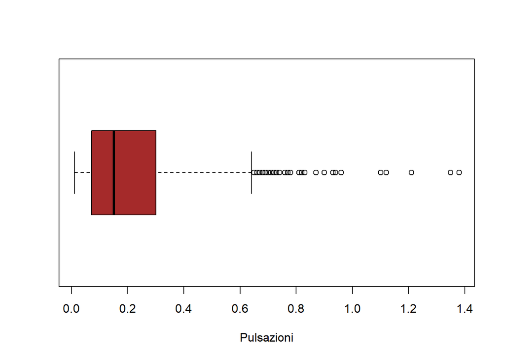

```r
boxplot(nervo$A, xlab="Pulsazioni", horizontal=TRUE, col = "brown")
```

We note that the median of 0.15 is more represented in the data than the mean.

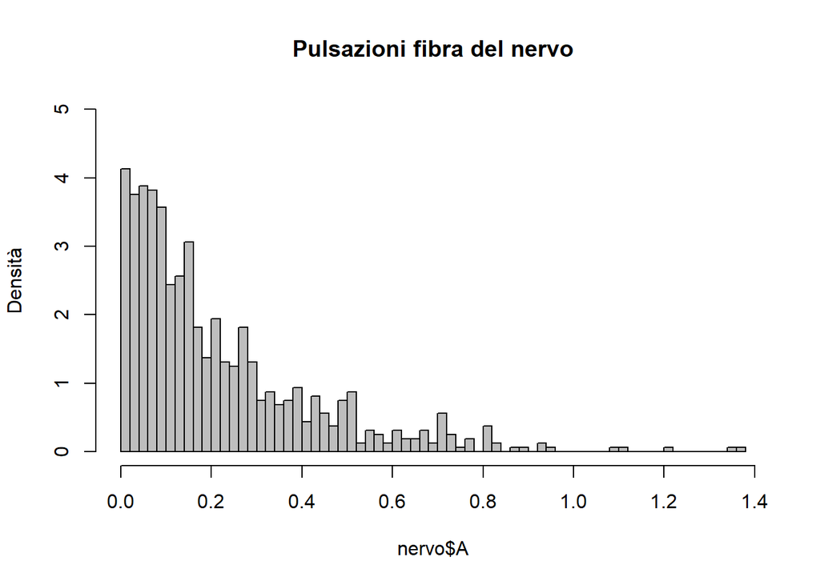

```r
hist(nervo$A,
breaks = 50,
ylim=c(0,5),
main = "Pulsazioni fibra del nervo",
ylab="Densità",
freq =FALSE,
col = "grey")
```

To verify, draw the exponential density curve with the average (1/rate) equal to that observed in the sample data and the empirical distribution is added, the rate is calculated

```r
rateA <- 1/mean(nervo$A); rateA
```

```
## [1] 4.575126
```

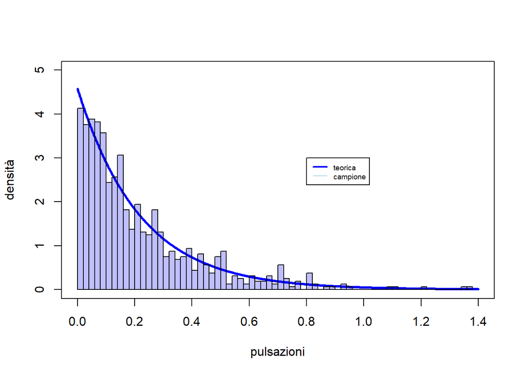

```r
x<-seq(0,1.4,length=799)
h<-dexp(x,rate = rateA)
plot(x,h,
ylim=c(0,5),
type="l", col = "blue",
lwd = 3,
xlab = "pulsazioni",
ylab = "densità")
hist(nervo$A,
breaks = 50,
col = rgb(0,0,1,1/4),
freq =FALSE, add=T)
legend(0.8,3, c("teorica", "campione"),
col = c("blue", "lightblue"),
lty = c(1,1),
lwd = c(2,1),
cex = 0.6)
```

Si disegna la funzione di ripartizione empirica che rappresenta lo stimatore di sostituzione plug-in della funzione di ripartizione teorica

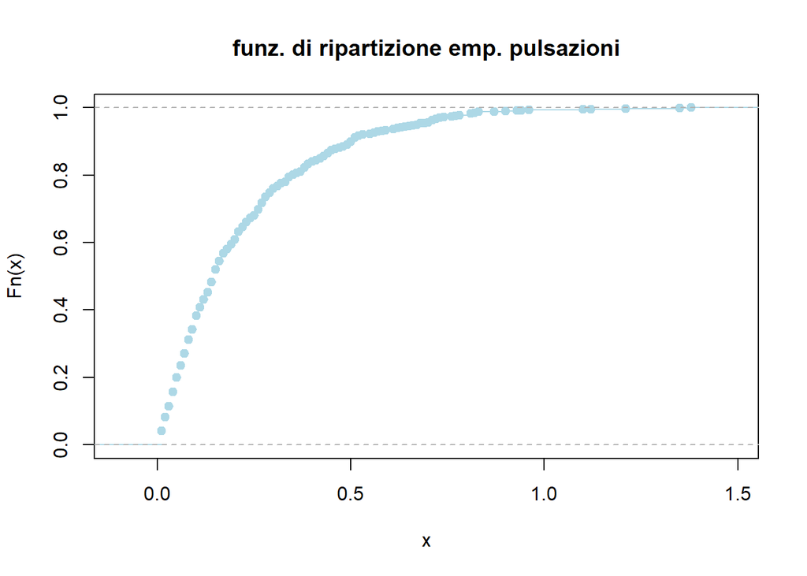

```r
plot(ecdf(nervo$A),
col="lightblue",
main= "funz. di ripartizione emp. pulsazioni")
```

The theoretical function is added to the empirical function

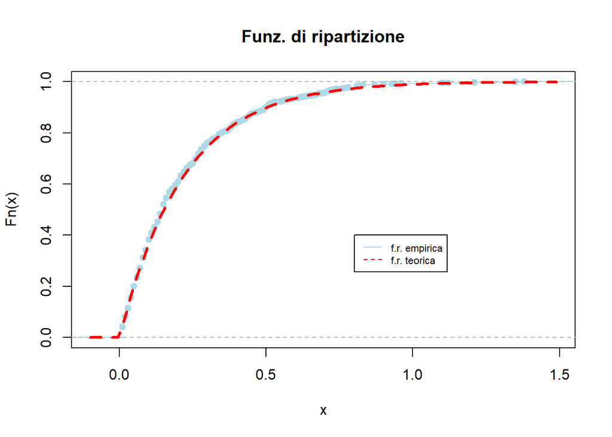

```r
plot(ecdf(nervo$A),
col="lightblue",
main= "Funz. di ripartizione")
#
curve(pexp(x,rate=rateA),
lty='dashed',
col='red',
lwd='3',
add=TRUE)
#
legend(0.8,0.4, col=c("lightblue","red"),
c("f.r. empirica","f.r. teorica"), lty=c(1,2),
cex=0.7)
```

### symmetry index Considering that for a random variable 𝑋 with mean 𝜇 and variance 𝜎2 the asymmetry is:
$$k =
E[\frac{(X-\mu)^3}{\sigma^3}]= \frac{\int (x-\mu)^3
dF(x)}{(\int(x-\mu)^2 F(x))^{3/2}}$$
and 𝜅 = 0 in the Normal distribution.

The usual estimate of the asymmetry index is obtained with the substitution estimator o plugin which is as follows

$$\hat{k}= T(\hat{F_n}) =\frac{\int
(x-\mu)^3 d\hat{F_n}(x)}{\hat{\sigma^3}} = \frac{\frac{1}{n}\sum_i^n(X_i
= \bar{X_n})^3}{\hat{\sigma^3}}$$

The function that calculates this index is present in the e1071 library

```r
require(e1071)
skewness(nervo$A)
```

```
## [1] 1.757943
```

### Bootstrap

Since the estimator 𝜅 has no known distribution, it can be associated with the point estimate of the aximetry obtained with the substitution estimator a measure of its variability. At this point it is necessary to apply the bootstrap method through the following steps: 1. It is determined: $X_1^* ...X_n^* \sim \hat{F_n}$ 2. The value of the statistic is calculated for each determination: $T_n^* = g(X_1^*...X_n^*)$

3. repeat steps 1 and 2 𝐵 times and the values are obtained: $T_{n,1}^* ...T_{n,B}^*$
4. The standard deviation is calculated:
   $$sd_{boot} = \sqrt{\frac{1}{B-1} \sum_{r=1}^B
   (T_{n,b}^* - \frac{1}{B} \sum_{r=1}^B (T_{n,r}^*})^2$$

STEP 1: the first sample is obtained from the original sample with the function sample which allows you to obtain n replications with replacement by specifying ’{replace= TRUE}

```r
n <- length(nervo$A)
B1 <- sample(nervo$A, n, replace = TRUE)
summary(B1)
```

```
##    Min. 1st Qu.  Median    Mean 3rd Qu.    Max.
##  0.0100  0.0700  0.1500  0.2143  0.2900  1.3800
```

- The second sample is obtained

```r
B2 <- sample(nervo$A, n, replace = TRUE)
summary(B2)
```

```
##    Min. 1st Qu.  Median    Mean 3rd Qu.    Max.
##  0.0100  0.0700  0.1500  0.2202  0.3200  1.3800
```

The third sample is obtained

```r
B3 <- sample(nervo$A, n, replace = TRUE)
summary(B3)
```

```
##    Min. 1st Qu.  Median    Mean 3rd Qu.    Max.
##  0.0100  0.0700  0.1500  0.2263  0.3200  1.3800
```

STEP 2: the value of the asymmetry index is calculated in each sample and the values obtained for each bootstrap replication are saved in the vector s

```r
s1<-skewness(B1)
s2<-skewness(B2)
s3<-skewness(B3)
s <- c(s1,s2,s3); s
```

```
## [1] 1.782246 1.967586 1.845939
```

or with the apply function

```r
BB<-cbind(B1,B2,B3)
apply(BB,2,skewness)
```

```
##       B1       B2       B3
## 1.782246 1.967586 1.845939
```

STEP 3: calculate the standard deviation of the bootstrap replications, this is the estimate for the standard error to be associated with the value of the asymmetry index calculated on sample of the original data through the plug-on estimator which is equal to 1.76.

Using only 3 bootstrap replications gives a standard error of

```r
sd(s)
```

```
## [1] 0.09416785
```

Obviously 𝐵 = 3 is not enough and the procedure must be repeated at least with 𝐵 = 200 bootstrap samples.

### Using the for loop

In the following code we sample 1000 times from the nerve vector and save the realized value on each sample of the asymmetry index in Tboot. Then the standard deviation of is calculated these achievements

```r
B <- 1000
n <- length(nervo$A)
Tboot <- rep(0, B)
set.seed(16253)
for (i in 1:B) {
Xstar <- sample(nervo$A,
n,
replace = TRUE)
Tboot[i] <- e1071::skewness(Xstar)
}
head(Tboot)
```

```
## [1] 1.608102 1.532254 1.751126 1.847124 1.608976 1.736952
```

```r
summary(Tboot)
```

```
##    Min. 1st Qu.  Median    Mean 3rd Qu.    Max.
##   1.223   1.630   1.742   1.743   1.850   2.444
```

```r
seTboot <- sd(Tboot); seTboot
```

```
## [1] 0.1694565
```

Obviously as with any other statistical procedure, it is essential that the data is sufficiently informative on the phenomenon of interest.

## Bootstrap confidence intervals

As in classical inference, in this context too it is preferable to report next to the point estimate for the parameter 𝜃 a confidence interval and the coverage probability called confidence level. ### Percentile method The data of the pulse times and the estimate of the asymmetry index are considered

```r
nervo<-read.table("data/nervo.dat", header = TRUE)
```

We obtain the bootstrap distribution using 𝐵=1000 samples and add the value of the estimate calculated in the observed data

```r
B <- 1000
n <- length(nervo$A)
Tboot <- rep(0, B)
for (i in 1:B) {
Xstar <- sample(nervo$A,
n,
replace = TRUE)
Tboot[i] <- e1071::skewness(Xstar)
}
```

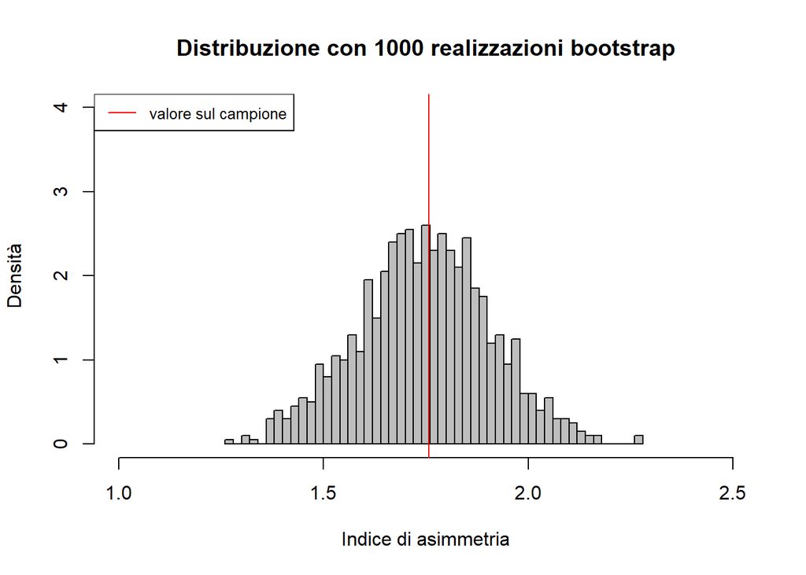

```r
sk <- e1071::skewness(nervo$A)
hist(Tboot,
breaks=50,
freq=FALSE,
main = "Distribuzione con 1000 realizzazioni bootstrap",
xlab = "Indice di asimmetria",
ylim = c(0,4),
col= "gray",
ylab = "Densità",
xlim = c(1,2.5))
abline(v=sk, col="red")
legend("topleft", 2,
c("valore sul campione"),
col = "red",
lty= 1,
cex = 0.8)
```

The bootstrap confidence interval obtained by the percentile method is calculated based on the empirical distribution of bootstrap replications. When using the percentile method, the extremes of the confidence interval are taken the quantiles of the distribution at a fixed confidence level, for example 0.95.

Therefore this is a 95% confidence interval for the skewness index.

We remember that: - The confidence interval is a range of values around the point estimate of parameter within which it is believed plausible that the true value of the parameter with a certain level of confidence. - The confidence level is a probability that must be referred to a confidence interval with random extremes in repeated sampling. - The value 0.95, however, is not the probability that $\theta$ belongs to the observed interval. - We have confidence that $\theta$ belongs to the observed interval because the procedure includes it in 95% of cases.

The histogram of the bootstrap distribution can be completed with the average value obtained from bootstrap replications and with the limits of the confidence interval

```r
sB<- mean(Tboot)
Q <- quantile(Tboot, c(0.025, 0.975))
Q[1]; Q[2]
```

```
##    2.5%
## 1.42489
```

```
##    97.5%
## 2.062046
```

```
#> 2.5%
#> 1.42489
#> 97.5%
#> 2.062046
```

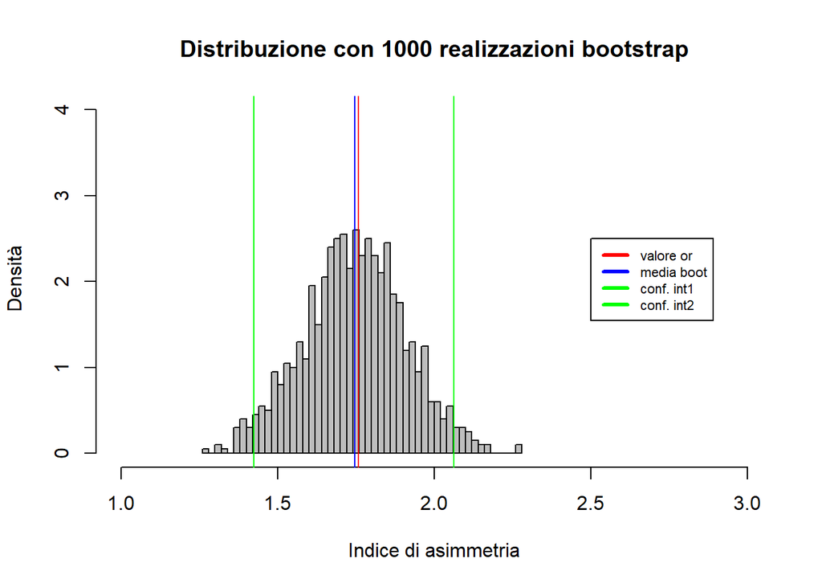

```r
#
hist(Tboot,
breaks = 60,
freq=FALSE,
main = "Distribuzione con 1000 realizzazioni bootstrap",
xlab = "Indice di asimmetria",
ylim = c(0,4),
col = "gray",
ylab = " Densità",
xlim = c(1, 3))
#
abline( v = c(sk,sB,Q[1], Q[2]),
col = c("red", "blue", "green", "green"))
#
legend(2.5,2.5,
c("valore or", "media boot",
"conf. int1", "conf. int2"),
col = c("red", "blue", "green", "green"),
lty = c(1,1,1,1),
lwd = c(3,3,3,3),
cex = 0.7)
```

## Bias Corrected Accelerated Bootstrap method

The confidence interval is calculated with the Bias Corrected Accelerated bootstrap method with the bcanon function present in the bootstrap library which requires as input the data vector, the number of bootstrap replications and the function (theta) referred to the estimator

```r
n
```

```
## [1] 799
```

```r
B<-1000
theta<-e1071::skewness
require(bootstrap)
set.seed(1013)
CIbca<-bcanon(nervo$A, B,
theta,
alpha = c(0.025, 0.975))
CIbca$confpoints
```

```
##      alpha bca point
## [1,] 0.025  1.470134
## [2,] 0.975  2.135836
```

It is noted that the lower and upper limits of the 95% confidence interval obtained with the bca method are 1.47 and 2.13, respectively. They differ from those calculated by the method of the percentile. In fact, the function also returns the estimated values of the two constants:

- acceleration $a$
- correction for distortion $z_0$ and these are non-zero

```r
CIbca$acc
```

```
## [1] 0.05746515
```

```r
CIbca$z0
```

```
## [1] 0.06019541
```

The range ends obtained with this method can be added to the graph as follows:

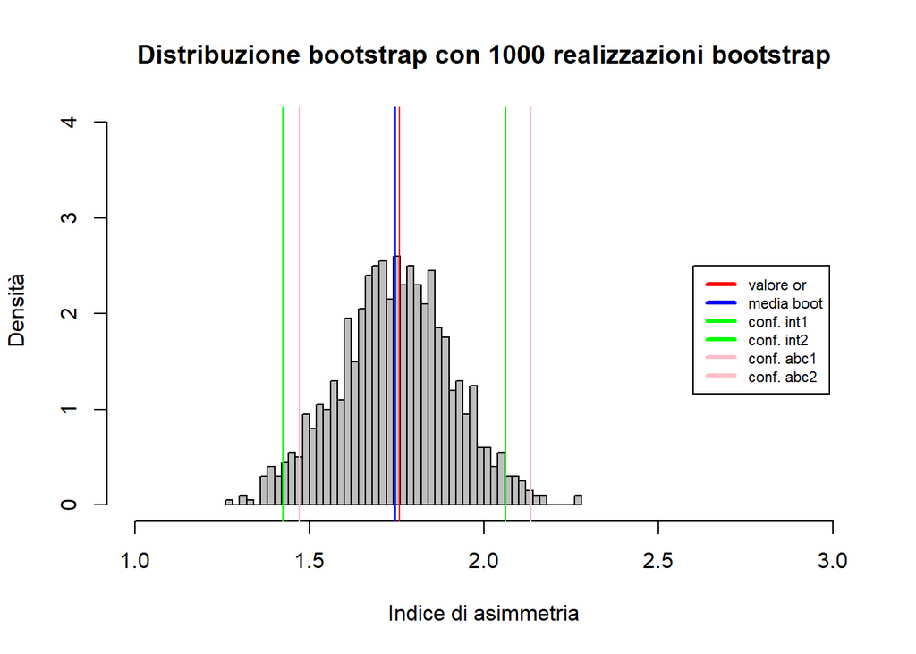

```r
hist(Tboot,
breaks = 60,
freq=FALSE,
main = "Distribuzione bootstrap con 1000 realizzazioni bootstrap",
xlab = "Indice di asimmetria",
ylim = c(0,4),
col = "gray",
ylab = " Densità",
xlim = c(1, 3))
#
abline( v = c(sk,
sB,
Q[1],
Q[2],
CIbca[["confpoints"]][3],
CIbca[["confpoints"]][4]),
col = c("red",
"blue",
"green",
"green",
"pink",
"pink"))
#
legend(2.6,2.5,
c("valore or",
"media boot",
"conf. int1",
"conf. int2",
"conf. abc1",
"conf. abc2"),
col = c("red",
"blue",
"green",
"green",
"pink",
"pink"),
lty = c(1,1,1,1,1,1),
lwd = c(3,3,3,3,3,3),
cex = 0.7)
```

The value of the asymmetry index for consecutive pulsations along the nerve fiber lies between these two extremes with a confidence of 0.95.

## Relative risk estimator: bootstrap confidence interval

The outer (marginal) frequencies are the corresponding row and column sums.

In cohort studies, individuals who have and do not have one are compared certain quality/pathology. In the context of prospective sampling (which differs from retrospective case-control sampling) are assumed as independent samples: the the first made up of exposed individuals and the second of non-exposed people. In this way the probability of the event can be estimated given the exposure.

Relative Risk (RR, relative risk or risk ratio) is an often used measure of association in the medical field to compare, for example, a response compared to two treatments.

It is calculated as the ratio between the frequency of those who present this characteristic (have had a heart attack) and have been exposed or have not been exposed (to aspirin). The measure is defined as the ratio between:

- the proportion of those exposed: those who had a heart attack and took aspirin 𝑁11 out of the total number of those who took aspirin 𝑁1.;
- the proportion of those not exposed: i.e. those who have had a heart attack and have not took aspirin 𝑁01 out of the total of those who did not take aspirin 𝑁0.

$$RR =
\frac{\frac{N_{11}}{N_{.1}}}{\frac{N_{01}}{N_{0.}}}$$
It is shown that 𝑅𝑅 = 1 is a sufficient and necessary condition for the independence between 𝑌 and 𝑋. The counts are considered v.c. having a Binomial distribution:

- $N_{01} \sim Bin(N_{0.}, p_0)$
- $N_{11} \sim Bin(N_{1.}.p_1)$
- $p_0=P(Y=1|X=0)$
- $p_1=P(Y=1)|X=1$

The maximum likelihood estimators for these probabilities are obtained as

$\hat{p_0} = \frac{N_{01}}{N_{0.}}$

$\hat{p_1} = \frac{N_{11}}{N_{1.}}$

and the maximum likelihood estimator for the relative risk (RR) is obtained
$$\hat{RR}=
\frac{\hat{p_1}}{\hat{p_0}}$$
In retrospective studies it is necessary to know the probability of exposure to estimate RR. If the latter is not known, the relative risk cannot be calculated and must be used the OR.

Another measure of association is the difference in probabilities whose rough estimate verisimilitude is obtained as

$$\hat{D}= \hat{p_1}
-\hat{p_0}$$

It is shown that the two random variables are statistically independent if

$𝑅𝑅 = 1; 𝐷 = 0; 𝑂𝑅 = 1.$ The distribution of relative risk is not known and even asymptotically cannot be approximated to the Normal one. In the following, the value of the relative risk is calculated and the bootstrap is used to obtain an interval estimate. ### Example It is assumed that there are 11034 people treated with placebo and 11037 treated with aspirin (independent samples) and that 104 patients had a heart attack among those treated with aspirin while 189 had a heart attack among those treated with placebo. They are considered the random variables 𝑋 and 𝑌 referring to the aspirin (X) and heart attack (Y) event. The maximum likelihood estimate of the relative risk RR for those treated with placebo it is

$\hat{p_1}= 189/11034= 0.0171$

while the other proportion for those treated with aspirin is $\hat{p_0}= 104/11037=0.009$

Hence the relative risk:
$$\hat{RR}=
\frac{0.0171}{0.009}= 1.81$$
is higher than 1: there is an association between the placebo and the heart attack, in fact based on this precise estimate, the probability of having a heart attack is approximately twice higher for the group of controls (i.e. patients treated with placebo) compared to the group treated (with aspirin). The following code creates the data set with the observations:

```r
X <- rep(c("aspirina","placebo"), c(11037,11034))
head(X)
```

```
## [1] "aspirina" "aspirina" "aspirina" "aspirina" "aspirina" "aspirina"
```

```r
table(X)
```

```
## X
## aspirina  placebo
##    11037    11034
```

The table is obtained with the table function which returns the table with the absolute frequencies.

```r
Y = rep(c("NO", "YES", "YES", "NO"),
c(11037-104, 104, 189,11034-189))
head(Y)
```

```
## [1] "NO" "NO" "NO" "NO" "NO" "NO"
```

```r
table(Y)
```

```
## Y
##    NO   YES
## 21778   293
```

The dataframe is built

```r
dataR <- data.frame(X,Y)
head(dataR)
```

```
##          X  Y
## 1 aspirina NO
## 2 aspirina NO
## 3 aspirina NO
## 4 aspirina NO
## 5 aspirina NO
## 6 aspirina NO
```

```r
table(dataR)
```

```
##           Y
## X             NO   YES
##   aspirina 10933   104
##   placebo  10845   189
```

The estimates of the two propositions can be obtained through the contingency table in which the absolute frequencies are divided by the marginal value of row (1)

```r
CC <- prop.table(table(dataR),1); CC
```

```
##           Y
## X                  NO        YES
##   aspirina 0.99057715 0.00942285
##   placebo  0.98287113 0.01712887
```

The estimate of the relative risk is obtained as the ratio between the two corresponding relative frequencies

```r
RR <- CC[4]/CC[3]; RR
```

```
## [1] 1.817802
```

A measure of accuracy for this estimate is obtained with bootstrapping. It is necessary to sample from the starting data the same unit for both columns each time. Using the loop iterative for

```r
B <- 2000
RRB <- rep(0,B)
n <- dim(dataR)[1]
set.seed(1023)
for(i in 1:B){
ind <-sample(1:n,
size = n,
replace = TRUE)
datB <- dataR[ind,]
CC <- prop.table(table(datB),1)
RR <- CC[4]/CC[3]
RRB[i]<-RR
}
head(RRB)
```

```
## [1] 1.985886 1.871075 1.628552 1.933696 1.563510 1.854757
```

```r
summary(RRB)
```

```
##    Min. 1st Qu.  Median    Mean 3rd Qu.    Max.
##   1.250   1.679   1.808   1.836   1.978   2.888
```

The standard error associated with the estimate is 0.23.

```r
sd(RRB)
```

```
## [1] 0.2281224
```

We draw the bootstrap distribution through the histogram

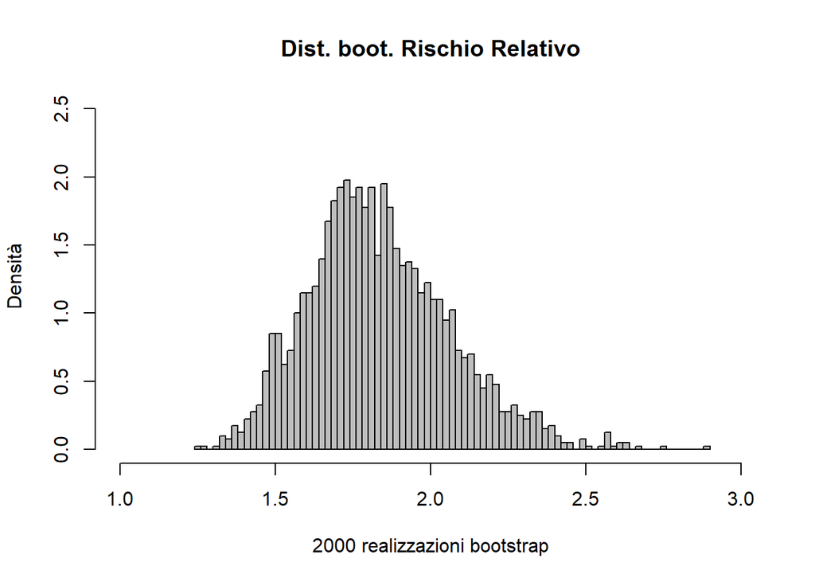

```r
sB<- mean(RRB)
hist(RRB,
breaks = 60,
freq=FALSE,
main = "Dist. boot. Rischio Relativo",
xlab = "2000 realizzazioni bootstrap",
ylim = c(0,2.5),
col = "gray",
ylab = " Densità",
xlim = c(1, 3))
```

## Percentile method

The 95% confidence interval is calculated using the percentile method. Using the percentile method the confidence interval is the central 95% of the distribution of bootstrap replications. That is, plausible estimates are those that fall between the 2.5th percentile and the 97.5th percentile of the bootstrap distribution.

```r
Q <- quantile(RRB, c(0.025,0.975)); Q
```

```
##     2.5%    97.5%
## 1.453375 2.338311
```

The distribution of the relative risk estimator obtained with the is represented graphically bootstrap

```r
Tm <- mean(RRB); Tm
```

```
## [1] 1.835642
```

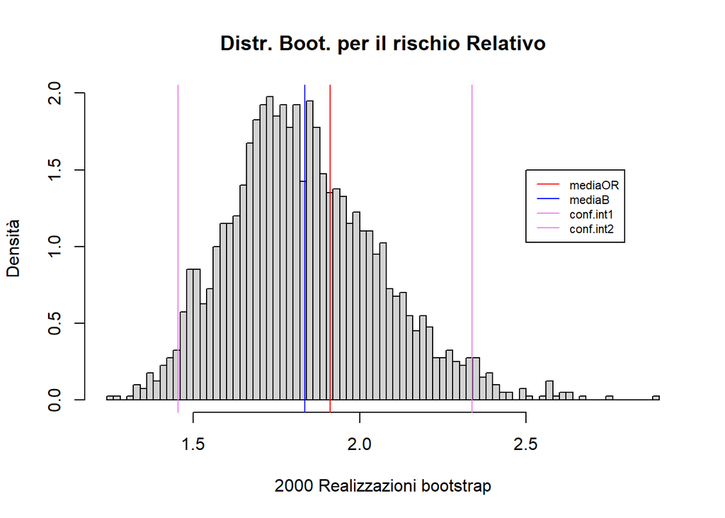

```r
hist(RRB,
main = "Distr. Boot. per il rischio Relativo",
breaks=60,
freq=FALSE,
ylab="Densità",
xlab="2000 Realizzazioni bootstrap")
abline(v=c(RR, Tm, Q[1], Q[2]),
       col=c("red","blue", "violet","violet"))
legend(2.5, 1.5,
c("mediaOR","mediaB", "conf.int1", "conf.int2"),
col=c("red","blue", "violet", "violet"),
lty=c(1,1,1,1),
cex=0.7)
```

```r
thetaR <- function(ind){
datB <- dataR[ind,]
CC <- prop.table(table(datB),1)
CC[4]/CC[3]
}
```

To obtain an interval at confidence level $1-\alpha$ = 0.95 the bcanon function is applied

```r
require(bootstrap)
set.seed(1023)
CIBca <- bcanon(1:n,
B,
thetaR,
alpha=c(0.025,0.975))
CIBca$confpoints
```

```
##      alpha bca point
## [1,] 0.025  1.411361
## [2,] 0.975  2.326449
```

```
#> alpha bca point
#> [1,] 0.025 1.411361
#> [2,] 0.975 2.326449
```

```r
CIBca$acc
```

```
## [1] -0.00603286
```

```
#> [1] -0.00603286
```

```r
CIBca$z0
```

```
## [1] -0.01504034
```

With a confidence of 0.95 we affirm that the probability of having a heart attack for those who do not were treated is higher by a value between 1.4 and 2.3 compared to that of those who have been treated with aspirin. Let’s add the Bca extremes to the previous graph

```r
Tm <- mean(RRB); Tm
```

```
## [1] 1.835642
```

```
#> [1] 1.835642
```

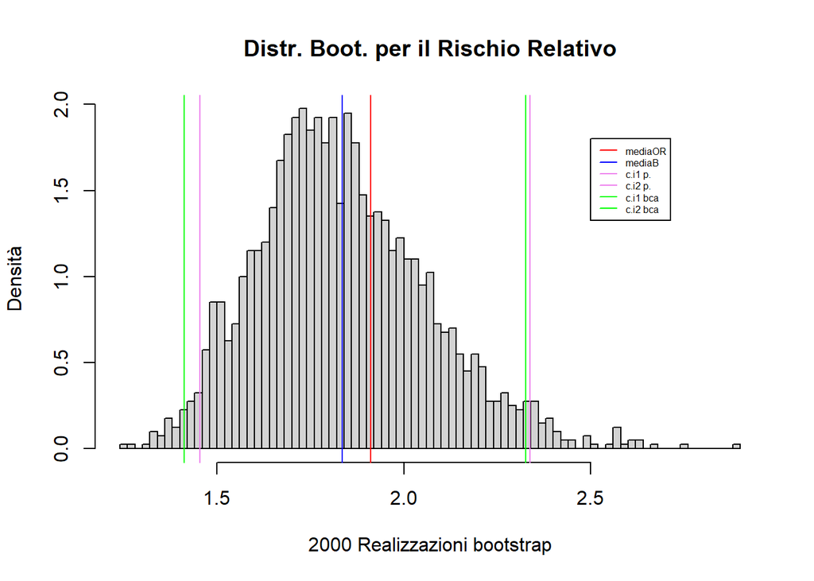

```r
hist(RRB,
main = "Distr. Boot. per il Rischio Relativo",
breaks=60,
freq=FALSE,
ylab="Densità",
xlab="2000 Realizzazioni bootstrap")
abline(v=c(RR, Tm, Q[1], Q[2],
CIBca[["confpoints"]][3],
CIBca[["confpoints"]][4]),
col=c("red","blue", "violet","violet", "green", "green"))
legend(2.5, 1.8,
c("mediaOR",
"mediaB",
"c.i1 p.",
"c.i2 p.",
"c.i1 bca",
"c.i2 bca"),
col=c("red","blue", "violet", "violet", "green", "green"),
lty=c(1,1,1,1),
cex=0.5)
```

Note that the bca range is slightly shifted to the left compared to that obtained with the percentile method.

# Excercise Bootstrap

## Exercise 23

The data present in the file called cranio1.Rdata concerns measurements at birth of the skull circumference (in cm) of 98 children born in the same month in one certain area (simulated data). 1. Illustrate the data using descriptive statistics. Draw the function of empirical distribution by comparing it with a plausible theoretical distribution. 2. Considering the average skull circumference, use the bootstrap to determine its accuracy measure using the function ’bootstrap::bootstrap‘. Report the result and comment. 3. Draw and comment on the bootstrap distribution by entering the calculated mean on the sample and the average of the bootstrap replications. 4. Draw the distribution of the estimation error and comment on it.

23.1

The data contained in the cranio1.RData file is loaded and the descriptive statistics are calculated.

```r
load("data/cranio1.Rdata")
skimr::skim_without_charts(cranio1)
```

Data summary

| Name | cranio1 |
| --- | --- |
| Number of rows | 98 |
| Number of columns | 1 |
| _______________________ |  |
| Column type frequency: |  |
| numeric | 1 |
| ________________________ |  |
| Group variables | None |

**Variable type: numeric**

| skim_variable | n_missing | complete_rate | mean | sd | p0 | p25 | p50 | p75 | p100 |
| --- | --- | --- | --- | --- | --- | --- | --- | --- | --- |
| data | 0 | 1 | 36.94 | 6.26 | 22.48 | 35.5 | 36.31 | 37.13 | 84.07 |

The dataset contains 98 observations for a single variable (the measurement of the skull circumference). The range of variation goes from a minimum of 23 cm to a maximum of 84 cm. The average circumference is of 37 cm, a value very close to that of the median. 75% of the newborns observed have a size of circumference less than 37cm. It is therefore observed that the maximum value (84 cm) is much higher to the remaining observations. The average variability around the mean is about 6 cm, a rather high value limited when compared to the average. To better evaluate the observed data, and in particular the value of the maximum compared to the rest of the observations, we represent them graphically.

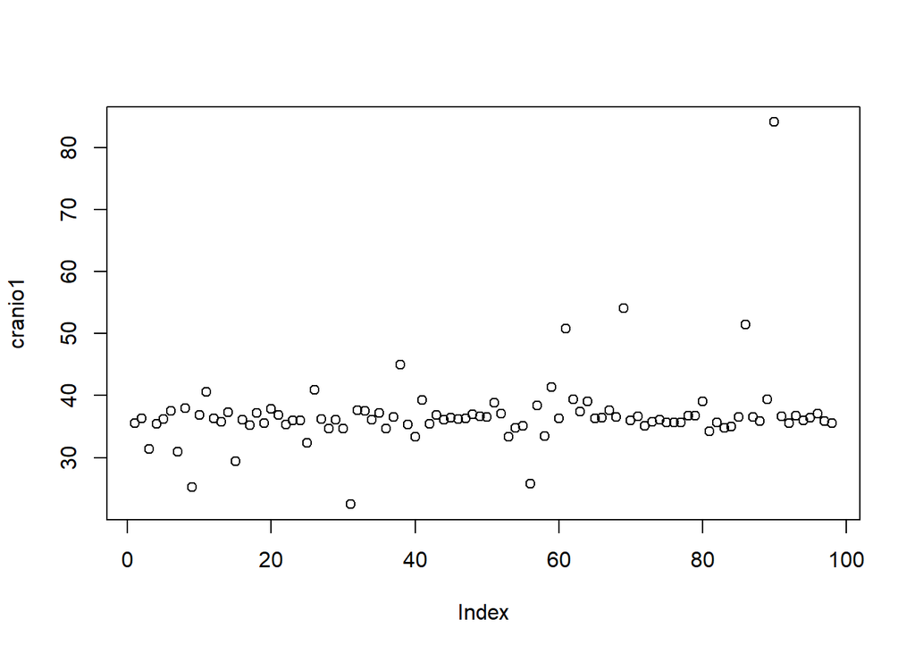

```r
plot(cranio1, type = "p")
```

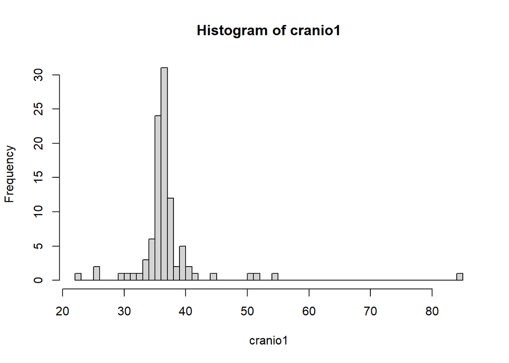

```r
hist(cranio1, breaks = 60)
```

A univariate Normal distribution is assumed for the V.C. the circumference measurement below of the skull; we then draw the empirical distribution function of the data together with that theory of a V.C. of Gauss, fixing the values of the parameters based on the sample statistics, that is, $𝑋 \sim 𝑁 (37, 36)$.

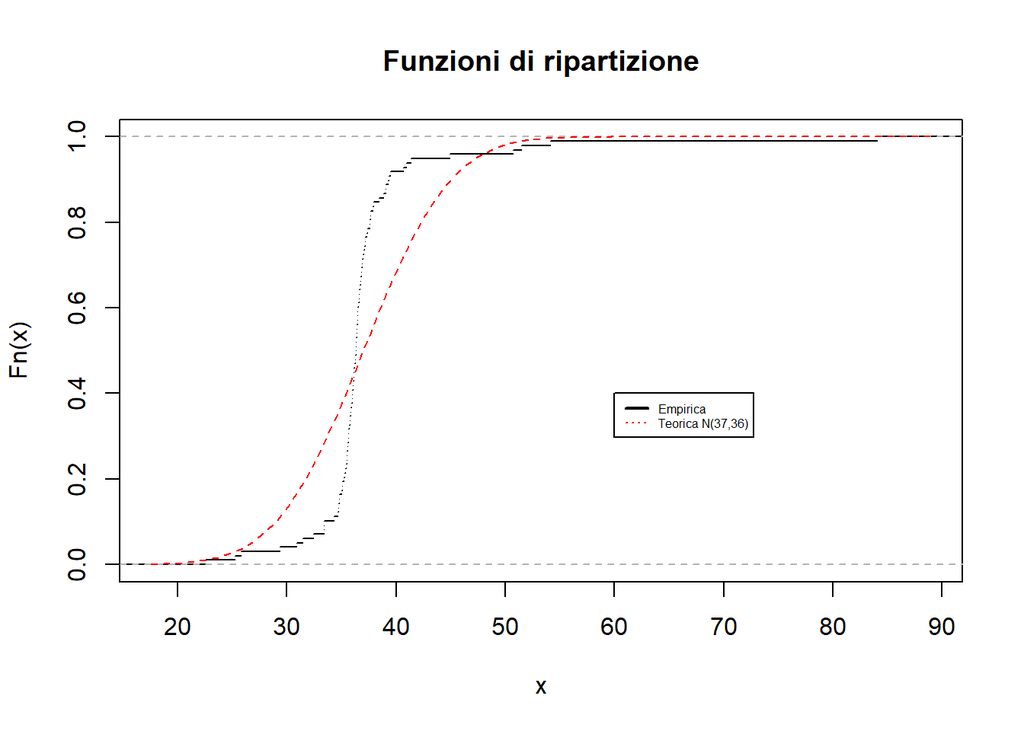

```r
ind <- which.max(cranio1)
plot(ecdf(cranio1),
do.points=FALSE,
main ='Funzioni di ripartizione')
curve(pnorm(x, 37, sd(cranio1)),
lty = 'dashed',
col = 'red',
add = TRUE)
legend(60, 0.4,
c("Empirica", "Teorica N(37,36)"),
col = c("black", "red"),
lty = c(1, 3),
lwd = c(2, 1),
cex = 0.5)
```

23.2

The estimate of the standard error (measure of accuracy) for the mean circumference is obtained with non-parametric bootstrap uses the bootstrap function of the package of the same name. This requires as input the name of the dataset, the number of replications, and the function you want to calculate on each replication. In this case, 2000 replications of the original dataset are considered.

```r
require(bootstrap)
set.seed(153)
b.boot <- bootstrap::bootstrap(cranio1, 2000, mean)
summary(b.boot$thetastar)
```

```
##    Min. 1st Qu.  Median    Mean 3rd Qu.    Max.
##   35.32   36.52   36.92   36.96   37.35   39.60
```

```r
sd(b.boot$thetastar)
```

```
## [1] 0.6463134
```

The accuracy measure is calculated through the standard deviation of the 2000 averages obtained through bootstrap replications; this value is equal to 0.64 and is rather limited.

23.3 The bootstrap distribution for the mean is drawn through the histogram of the 2000 calculated means on bootstrap replications of the original dataset.

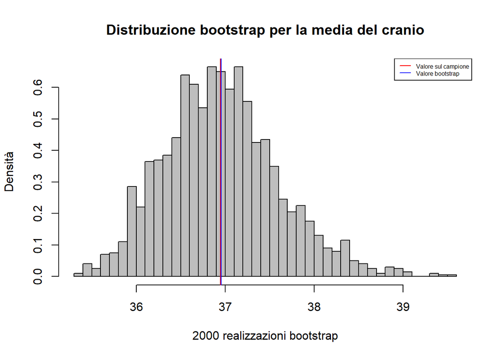

```r
temp <- range(b.boot$thetastar)
hist(b.boot$thetasta,
breaks = 50,
freq = FALSE,
main = "Distribuzione bootstrap per la media del cranio",
xlab = "2000 realizzazioni bootstrap",
# xlim = temp,
# ylim = c(0,0.7),
col = "gray",
ylab = "Densità")
abline(v = mean(cranio1), col = "red")
abline(v = mean(b.boot$thetastar), col = "blue")
legend("topright",
c("Valore sul campione", "Valore bootstrap"),
col = c("red", "blue"),
lty = c(1, 1),
cex = 0.5)
```

The bootstrap distribution for the means of skull choroconference measurements looks quite good symmetrical. The average calculated on the original sample and the average of the 2000 averages on the bootstrap replications are coincident (overlapping in the graph) and are located in the peak center of the histogram.

23.4

We graphically represent the distribution of the estimate error, calculated as the difference between the average calculated on the original sample and the average calculated on each bootstrap sample.

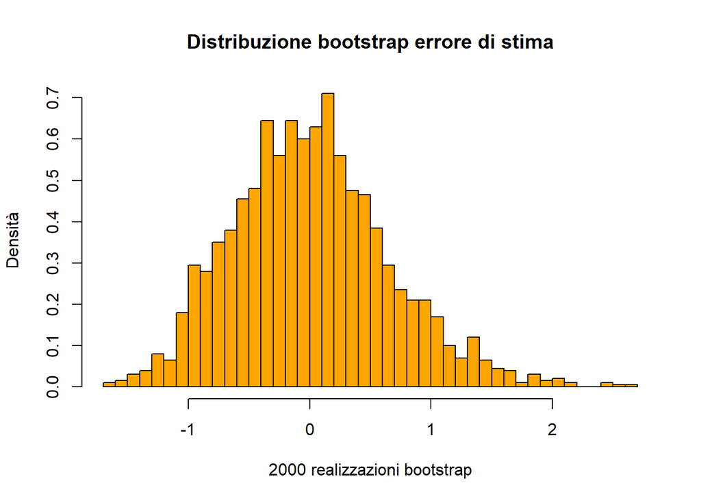

```r
dif <- b.boot$thetastar - mean(cranio1)
hist(dif,
breaks = 50,
freq = FALSE,
main = "Distribuzione bootstrap errore di stima",
xlab = "2000 realizzazioni bootstrap",
col = "orange",
ylab = "Densità")
```

The distribution of the estimation error is approximately symmetric, centered around 0. The range of variation is rather limited, going from a minimum of -2 to a maximum slightly higher to 2. Furthermore, most of the observations are located in the central area, a sign of an error of particularly limited estimate.

## EXERCISE 24

Consider the weight of 3 mice measured in the laboratory: 80, 103 and 91 grams. 1. Report the average weight. 2. Report the possible number of bootrstrap samples. 3. List all possible bootstrap samples. 4. Report the means obtained for each of the bootstrap samples. 5. Report the mean of the means obtained from the bootstrap samples and compare it with the average weight of the source sample. 6. Determine the minimum and maximum values of each bootstrap sample.

24.1 Average weight value: 91.3 g.

```r
x <- c(80, 103, 91)
mean(x)
```

```
## [1] 91.33333
```

```r
n <- length(x)
choose(2*n-1, n)
```

```
## [1] 10
```

24.3

Possible Bootstrap samples: (80, 80, 80), (80, 80, 91), (80, 80, 103), (80, 91, 91), (80, 103, 103), (80, 91, 103), (91, 91, 91), (91, 91, 103), (91, 103, 103), (103, 103, 103). We collect them in the df dataframe; each column corresponds to a different replication.

```r
df <- data.frame(c(80, 80, 80), c(80, 80, 91), c(80, 80, 103), c(80, 91, 91), c(80, 103, 103),
c(80, 91, 103), c(91, 91, 91), c(91, 91, 103), c(91, 103, 103),c(103, 103, 103))
colnames(df) <- as.character(1:10)
df
```

```
##    1  2   3  4   5   6  7   8   9  10
## 1 80 80  80 80  80  80 91  91  91 103
## 2 80 80  80 91 103  91 91  91 103 103
## 3 80 91 103 91 103 103 91 103 103 103
```

24.4

Averages (in the same order as the samples written in the previous point): 80.0, 83.7, 87.7, 87.3, 95.3, 91.3, 91.0, 95.0, 99.0, 103.0.

```r
medie_bootstrap <- round(apply(df, 2, mean), 1)
```

24.5

Means of the means obtained from the bootstrap samples: 91.3 The value coincides with the determined one on the original sample in step 1.

```r
mean(medie_bootstrap)
```

```
## [1] 91.33
```

24.6

Minimum values:

```r
apply(df, 2, min)
```

```
##   1   2   3   4   5   6   7   8   9  10
##  80  80  80  80  80  80  91  91  91 103
```

Maximum values:

```r
apply(df, 2, max)
```

```
##   1   2   3   4   5   6   7   8   9  10
##  80  91 103  91 103 103  91 103 103 103
```

## Exercise 25

The protein contents of wheat and camut were detected for different types of product. Consider the following values in grams: - Wheat: 176, 125, 152, 180, 159, 168, 160, 151; - Camut: 164, 121, 137, 169, 144, 145, 156, 139. 1. Illustrate the data using descriptive statistics and graphical representations and calculate the averages of the measurements for the two cereals. 2. Consider the difference between the arithmetic means. Apply the bootstrap method using the for loop with number of bootstrap replications equal to 1000 per obtain the standard error for this difference. Comment on the result. 3. Draw the bootstrap distribution. 4. Apply the bootstrap method as in point .2 instead considering the difference between the two medians. Comment on the result.

25.1 The data are collected in two vectors and the descriptive statistics and analyzes are carried out graphic representations.

```r
grano <- c(176, 125, 152, 180, 159, 168, 160, 151)
camut <- c(164, 121, 137, 169, 144, 145, 156, 139)
dat <- data.frame(grano, camut)
summary(dat)
```

```
##      grano           camut
##  Min.   :125.0   Min.   :121.0
##  1st Qu.:151.8   1st Qu.:138.5
##  Median :159.5   Median :144.5
##  Mean   :158.9   Mean   :146.9
##  3rd Qu.:170.0   3rd Qu.:158.0
##  Max.   :180.0   Max.   :169.0
```

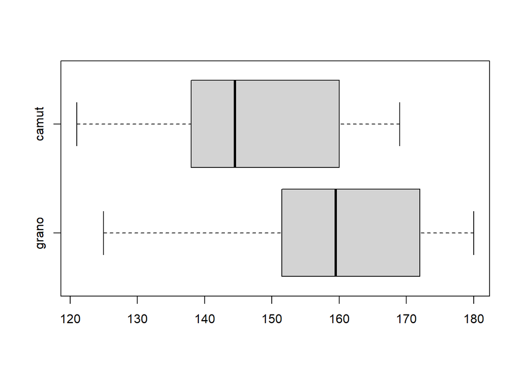

```r
boxplot(dat, horizontal = T)
```

```r
n <- dim(dat)[1]
B <- 1000
DDB <- rep(0, B)
set.seed(123)
for(i in 1:B){
ind <- sample(1:n, size = n, replace = TRUE)
Y <- dat[ind,"grano"]
Z <- dat[ind,"camut"]
CC <- mean(Y)-mean(Z)
DDB[i] <- CC
}
summary(DDB)
```

```
##    Min. 1st Qu.  Median    Mean 3rd Qu.    Max.
##    4.00   10.50   11.88   11.86   13.25   19.62
```

Considering 1000 bootstrap repetitions the difference between the wheat and camut averages varies from a minimum of 4 to a maximum of almost 20. The average value of the difference is instead equal to 12, approximately equal to the median. The two indices coincide with the value of the difference between the averages calculated on the original sample. Try implementing the same request using the bootstrap::bootstrap function; Yes compare the results. (Hint: build a function that receives the corresponding rows as input to the bootstrap replication and calculate the difference of the means. Apply this function to the command bootstrap)

NOTE: in carrying out this exercise each resampling is carried out jointly for the two surveys: an index 𝑖 ∈ {1, … , 𝑛} is extracted (randomly and with re-entry) and consider the 𝑖-th element of both the grain vector and the camut vector. In general it could also proceed independently: I extract two indices 𝑖, 𝑗 ∈ {1, … , 𝑛} and consider the 𝑖-th element of the grain vector and the 𝑗-th of the camut vector. The definition of the most appropriate method depends from individual applications. In our case the two original datasets seem to be considered jointly: it is sufficient to plot them in the Cartesian plane (plot(grain, camut)), or more simply calculate the correlation index to detect that they are strongly (and positively) linearly associated. In other applications it may be more appropriate to proceed instead by considering the two dataset independently.

25.3

The bootstrap distribution is represented graphically in the form of a histogram. They add then the lines corresponding to the difference calculated on the original dataset and the average of the differences calculated on bootstrap datasets.

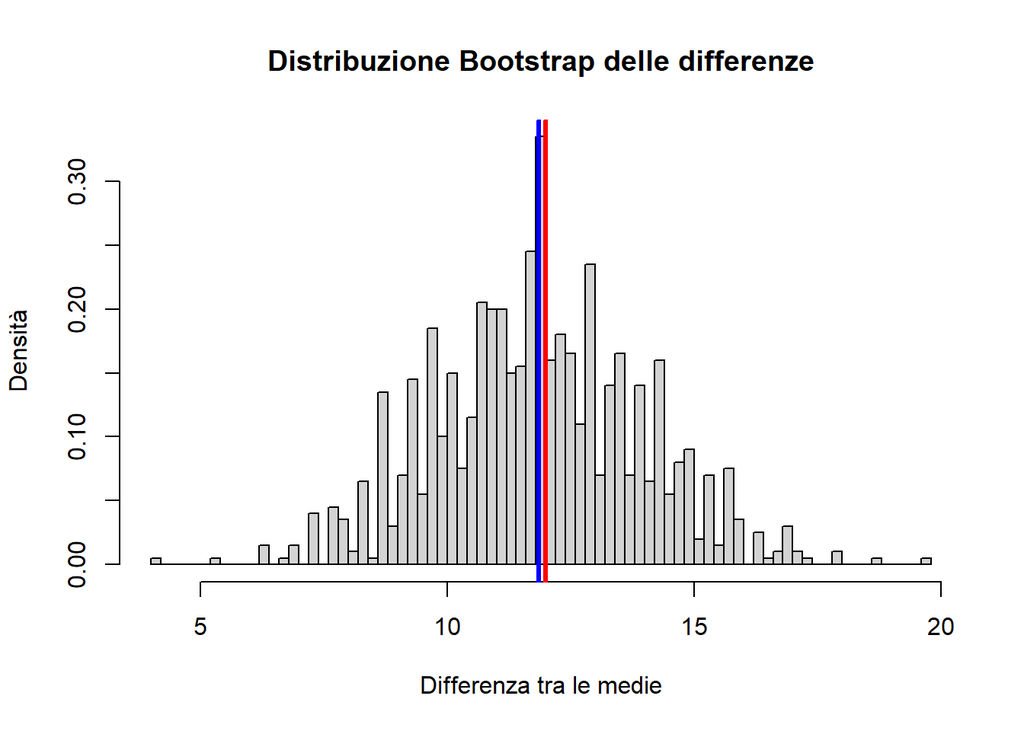

```r
diff <- mean(grano)-mean(camut)
B_diff <- mean(DDB)
hist(DDB,
main = "Distribuzione Bootstrap delle differenze",
breaks = 60,
freq = FALSE,
ylab = "Densità",
xlab = "Differenza tra le medie")
abline(v = c(diff, B_diff),
col = c("red", "blue"),
lwd = c(3, 3))
legend(15, 0.7,
c("difOR", "difB"),
col = c("red", "blue"),
lty = c(1, 1),
cex = 0.6)
```

The range of variation, as already described previously, varies approximately between 5 and 20. The distribution it is approximately symmetrical around the central peak, located around the value 12, and coincident both with the difference between the means calculated on the original data and with the average of the differences bootstrap.

25.4

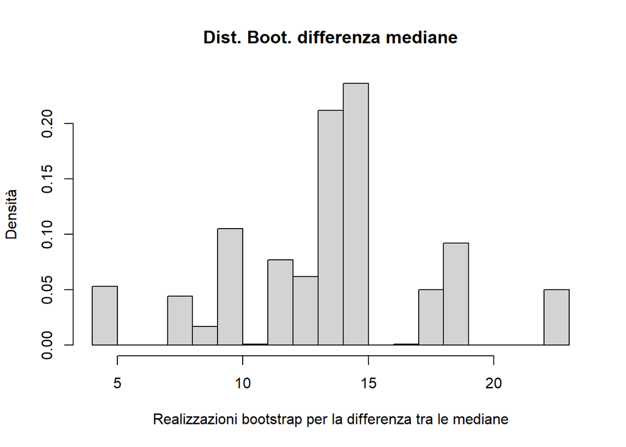

```r
DDB <- rep(0,B)
set.seed(123)
for(i in 1:B){
ind <-sample(1:n, size = n, replace = TRUE)
Y <- dat[ind,"grano"]
Z <- dat[ind,"camut"]
CC<- median(Y)-median(Z)
DDB[i] <- CC
}
hist(DDB,
main = "Dist. Boot. differenza mediane",
breaks = 15,
freq = FALSE,
ylab = "Densità",
xlab = "Realizzazioni bootstrap per la differenza tra le mediane")
```

In this case we note that the differences between the medians calculated on the bootstrap samples trend to always take on a limited number of values. For example, a high number of differences with values between 13 and 15 and almost nothing between 15 and 17. This can be explained by the few observations originally available: bootstrapping tends to repeat observations and accordingly also the values of the final result. In this case with the bootstrap it is not possible to estimate some quantiles of the distribution.

## Exercise 26

26.1 The data is loaded into a vector and the descriptive statistics and main representations are provided graphics. Comments are left to the student.

```r
x <- c(23, 16, 21, 24, 34, 28, 28, 28, 24, 30, 28, 24, 26, 18,
23, 23, 36, 37, 49, 50, 51, 56, 46, 41, 54, 30, 40, 31)
summary(x)
```

```
##    Min. 1st Qu.  Median    Mean 3rd Qu.    Max.
##   16.00   24.00   29.00   32.82   40.25   56.00
```

```r
sd(x)
```

```
## [1] 11.41491
```

Mean and median, which will be analyzed with the bootstrap technique in the next points of the financial year, are worth 33 and 29 respectively.

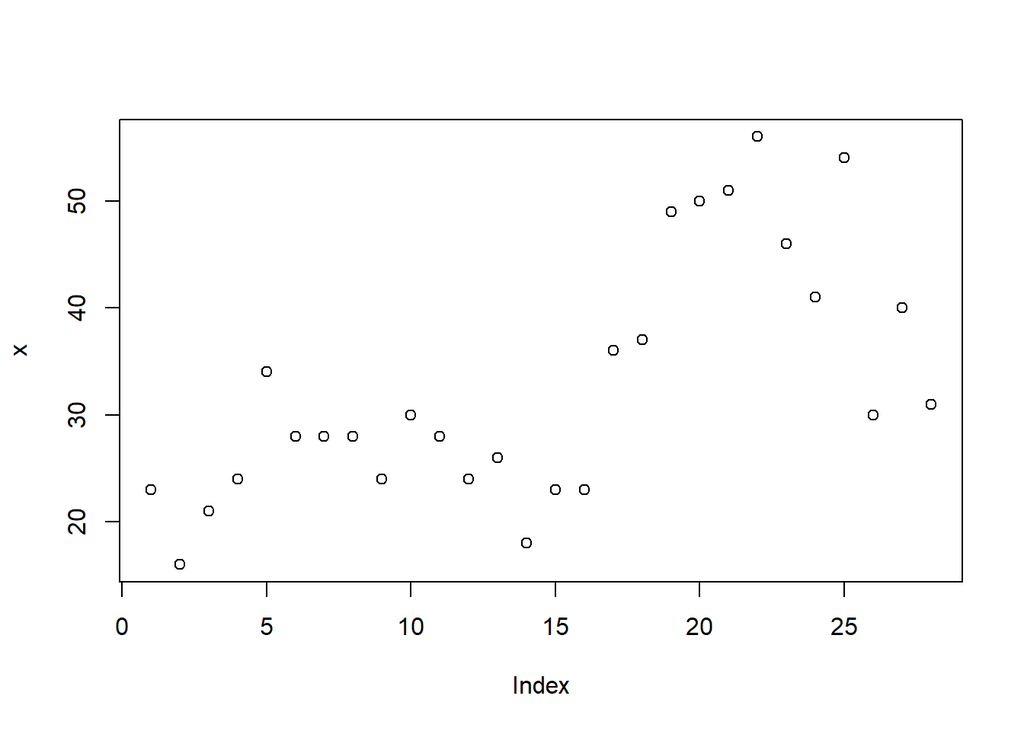

```r
plot(x)
```

It is noted that the first findings all present low values (less than 40) for the number of cases of rare tumor. The latest findings, however, take much higher values.

26.2

To apply the bootstrap procedure (with the bootstrap::bootstrap command), we first define the function needed to calculate the mean and median on bootstrap samples. The implemented bootstrap::bootstrap function executes the bootstrap procedure by sampling in randomly and with reinsertion of the indexes of the rows of the original dataset. The number of different replications is set at 3000.

```r
n <- length(x)
B <- 3000
set.seed(2410)
mean_B <- bootstrap::bootstrap(1:n, B, function(i) mean(x[i]))
set.seed(2410)
median_B <- bootstrap::bootstrap(1:n, B, function(i) median(x[i]))
```

Note that setting the same value for the prim seed of both function calls bootstrap::bootstrap uses the same samples for both the averaged and averaged calculations with the medians. We now analyze the results relating to the two indices by calculating the standard error.

```r
sd(mean_B$thetastar)
```

```
## [1] 2.161022
```

```r
sd(median_B$thetastar)
```

```
## [1] 2.650219
```

It is observed that both values of the standard error are rather contained; the accuracy for both estimators (sample mean and median), estimated through the bootstrap method on base of 3000 replications of the original sample, is therefore high. In particular that the value of the standard error for the mean is slightly lower than that for the median; it is known that the bootstrap method does not always work optimally for quartiles.

26.3

We report the histograms of the two bootstrap distributions in a single graphic window.

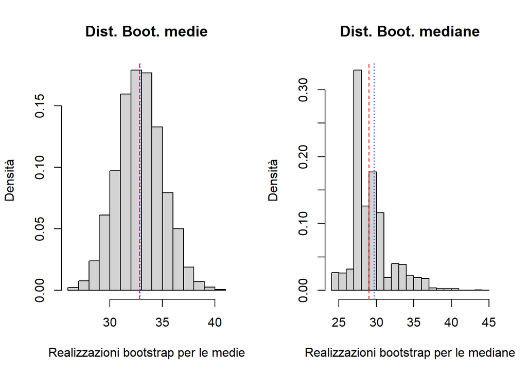

```r
par(mfrow = c(1, 2))
hist(mean_B$thetastar,
main = "Dist. Boot. medie",
breaks = 15,
freq = FALSE,
ylab = "Densità",
xlab = "Realizzazioni bootstrap per le medie")
abline(v = mean(x), col = "red", lty = 2)
abline(v = mean(mean_B$thetastar), col = "blue", lty = 3)
hist(median_B$thetastar,
main = "Dist. Boot. mediane",
breaks = 15,
freq = FALSE,
ylab = "Densità",
xlab = "Realizzazioni bootstrap per le mediane")
abline(v = median(x), col = "red", lty = 2)
abline(v = mean(median_B$thetastar), col = "blue", lty = 3)
```

The two graphs appear significantly different from each other. The one relating to the average is almost perfectly symmetrical; the average values on the original dataset and the average on the 3000 values bootstrap coincide with each other and are positioned at the central peak. Resampling bootstrap, however, was not as effective as regards the mediama: the form of the histogram is not symmetrical, showing a single very high peak in correspondence of a value between 27 and 28 (not in the center of the distribution). This peak does not coincides neither with the median calculated on the original dataset, nor with the average of the calculated medians on the 3000 bootstrap samples. Furthermore, these two values are themselves not coincident. The range of this bootstrap distribution is wider than that obtained in the case of the average. Regarding the bias of the two estimators, we calculate the difference between the value of estimator obtained on the original dataset and the average of the bootstrap values.

```r
mean(mean_B$thetastar) - mean(x)
```

```
## [1] 0.04861905
```

The distortion obtained for the mean estimator is very low (equal to 0.05), a sign that the estimator (sample mean) is not distorted. On the contrary, the value of the distortion for the median is 0.7, indicating a slight bias for the corresponding estimator.

26.4

Please refer to the solutions of the previous points and exercises.

## Exercise 27

Consider the data present in the file called warfarin.Rdata. There are two of them measures of the anticoagulant that is used in heart patients. The first measurement (cread) is obtained in the clinic while the second (lread) is obtained in the laboratory. (Data taken from Riffenburgh R. H. 2012. Statistics in Medicine, Academic Press.) 1. Describe the observed data. 2. Report and interpret the value of the ratio between the two arithmetic means. This allows you to evaluate whether there is an average difference between the two tests. 3. Use the bootstrap method with the bootstrap library functions to obtain the standard error for the estimate referred to in the previous point.

27.1

The dataset is loaded and the main descriptive statistics are analysed. `

```r
load("data/warfarin.Rdata")
skimr::skim_without_charts(warfarin[, -1])
```

Data summary

| Name | warfarin[, -1] |
| --- | --- |
| Number of rows | 104 |
| Number of columns | 2 |
| _______________________ |  |
| Column type frequency: |  |
| numeric | 2 |
| ________________________ |  |
| Group variables | None |

**Variable type: numeric**

| skim_variable | n_missing | complete_rate | mean | sd | p0 | p25 | p50 | p75 | p100 |
| --- | --- | --- | --- | --- | --- | --- | --- | --- | --- |
| cread | 0 | 1 | 2.40 | 0.54 | 1.21 | 2.1 | 2.38 | 2.7 | 4.01 |
| lread | 0 | 1 | 2.28 | 0.63 | 1.10 | 1.9 | 2.15 | 2.6 | 3.70 |

There are 104 individuals, for whom measurements of two variables are taken. The two distributions they have a very similar range of variation, taking only positive values, and with a maximum around 4. The average of the anticoagulant measurements taken in the clinic is higher than that of the values detected in the laboratory. Conversely, these measurements are more variable, having a higher standard deviation value than those detected in the clinic. We now represent the observations in the Cartesian plane (scatter plot), using colors different for measurements in the clinic and those in the laboratory.

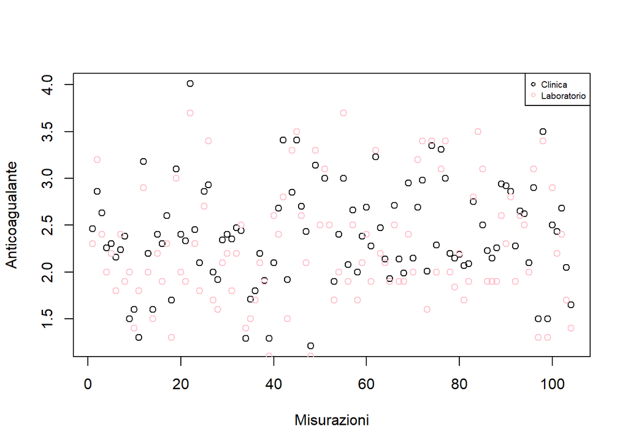

```r
plot(warfarin[, 2],
ylab="Anticoagualante",
main = "",
xlab = "Misurazioni")
points(warfarin[, 3],
col="pink")
legend("topright",
col = c("black", "pink"),
c("Clinica", "Laboratorio"),
pch = c(1, 1),
cex = 0.6)
```

The values obtained through both types of measurement are arranged uniformly in the plane, without forming particular point structures (patterns) or prevalence of one of the two methods measurement in certain regions of the plane. The values obtained in the clinic appear to be higher compared to those obtained in the laboratory, but the difference is extremely limited (as already seen with descriptive statistics). We also represent the two empirical distribution functions in the same graph so as to be able to compare them.

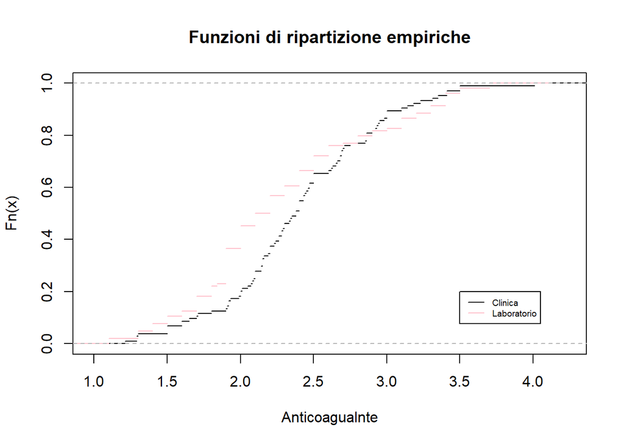

```r
plot(ecdf(warfarin[, 2]),
col = "black",
xlab = "Anticoagualnte",
do.points = FALSE,
main = "Funzioni di ripartizione empiriche")
plot(ecdf(warfarin[, 3]),
col = "pink",
do.points = FALSE,
add = TRUE)
legend(3.5, 0.2,
col = c("black", "pink"),
c("Clinica", "Laboratorio"),
lty = c(1, 1),
cex = 0.6)
```

With the same abscissa (i.e. anticoagulant measurement), and up to the value 𝑥 = 2.7, the function distribution for values obtained in clinic is lower than that for values obtained in laboratory. In other words, for values 𝑥 ≤ 2.7 of anticoagulant, the probability ℙ(𝑋𝐶𝑙𝑖𝑛𝑖𝑐𝑎 ≤ 𝑥) is always less than the probability $ℙ(𝑋_{lab}𝑥). The situation is reversed for values of 𝑥 above 2.7. The slope of both curves attenuates for high anticoagulant values.

27.2

The plug-in estimator for the ratio between the arithmetic means is applied, where 𝐶 denotes the measurements in the clinic and with 𝐿 those in the laboratory: $\theta_{\text{plug-in}} = \frac{C}{L}$

```r
th <- mean(warfarin$cread)/mean(warfarin$lread); th
```

```
## [1] 1.054828
```

We note that the estimate $\theta_{\text{plug-in}}$ on the sample is 1.05, i.e. slightly higher than 1. It should be considered that the estimator is biased as it is the ratio between two arithmetic means.

27.3

To obtain the standard error of the estimate calculated in the previous point, the function is used bootstrap::bootstrap; we therefore first implement the function that defines the plugin estimator of interest for a generic bootstrap sample. This function requires the argument as input numeric that defines the position of the ind units that are used for the bootstrap sample once at a time and returns the plug-in estimate calculated on that sample.

```r
theta1 <- function(ind) {
Y <- warfarin[ind, 2]
Z <- warfarin[ind, 3]
mean(Y)/mean(Z)
}
```

The bootstrap::bootstrap function performs the bootstrap procedure by sampling randomly and with reinsertion of the indexes of the rows of the original dataset. The number of different replications is set at 2000.

```r
n <- dim(warfarin)[1]
B <- 2000
set.seed(18243)
bootw <- bootstrap::bootstrap(1:n, B, theta1)
head(bootw$thetastar)
```

```
## [1] 1.056795 1.056041 1.034042 1.058653 1.040985 1.049019
```

```r
summary(bootw$thetastar)
```

```
##    Min. 1st Qu.  Median    Mean 3rd Qu.    Max.
##   1.006   1.046   1.055   1.055   1.064   1.096
```

The minimum value is equal to 1.006, confirming that none of the bootstrap estimates take on value less than 1. The maximum value is instead 1.096, thus denoting a very limited range. Average and median coincide with each other and approximately with the value of the calculated ratio between the means on the original dataset. The standard deviation of the bootstrap replications allows us to evaluate the variability due to random sampling (standard error).

```r
sd(bootw$thetastar)
```

```
## [1] 0.01262892
```

Finally, the difference found between the parameter estimate calculated on the original data and the one is calculated average value obtained through the bootstrap.

```r
Tm1 <- mean(bootw$thetastar)
Tm1 - th
```

```
## [1] 0.0002483279
```

This value is rather small; the distortion is therefore negligible and does not need to be corrected the estimate.

## Exercise 28

1. With reference to Exercise 25, determine the 95% confidence intervals for the difference between the two means and for the difference between the two medians with the percentile method and with the Bca method. Comment on the results and drawings the bootstrap distribution indicating both the value realized on the sample and the mean value in bootstrap replications, the extremes of the two intervals together to the legend. Comment on the graph.
2. With reference to Exercise 26, determine the 95% confidence intervals for both the mean and the median with the percentile method and with the method Bca. Comment on the graph drawn as in the previous point.
3. With reference to Exercise 27, determine the 90% confidence intervals for the ratio between the two arithmetic means with the percentile method and with the Bca method. Comment on the graph drawn as in the previous point.

SOLUTIONS TO EXERCISE 28

28.1

Please refer to the solutions in point 28.3.

28.2

Please refer to the solutions in point 28.3.

28.3

The data relating to Exercise 27 regarding anticoagulant measures are considered. The interval is reported confidence at the 90% level for the ratio between the means obtained with the percentile method e with the Bias Corrected Accelerated Bootstrap (BCAB) method. Please note that the quantities already entered in exercise 27 they are not recalculated here. The bootstrap confidence interval calculated by the percentile method is based on the distribution empirical of bootstrap replications. Quantiles are used as limits of the confidence interval appropriate for the distribution of bootstrap replications. In particular, by setting the coverage level at 0.90, the extremes considered are determined the fifth and ninety-fifth percentiles. The quantile command allows you to calculate quantiles specified.

```r
Q <- quantile(bootw$thetastar, c(0.05,0.95)); Q
```

```
##       5%      95%
## 1.034852 1.075985
```

At the 90% confidence level we note that the interval always contains values greater than 1; we can therefore conclude that the values detected in the clinic are significantly higher than those detected in the laboratory. For the calculation of the confidence interval (at the 90% confidence level) with the BCAB method yes instead use the bcanon function from the bootstrap package. This requires the same arguments of the bootstrap function (range of values on which to resample, number of copies bootstrap, function to apply) in addition to the confidence level value. Let’s remember this confidence interval corrects for bias and uses an acceleration constant.

```r
require(bootstrap)
set.seed(1023)
n <- dim(warfarin)[1]
CIBca <- bootstrap::bcanon(1:n, nboot = 2000, theta1, alpha = c(0.05,0.95))
CIBca$confpoints
```

```
##      alpha bca point
## [1,]  0.05  1.032924
## [2,]  0.95  1.076306
```

```r
CIBca$acc
```

```
## [1] -0.01751753
```

```r
CIBca$z0
```

```
## [1] 0.03133798
```

We can also obtain values for the acceleration and distortion constants, equal to -0.02 and 0.03 respectively, both different from zero (albeit slightly). Finally we add the extremes of the confidence intervals obtained with the two methods to the representation graphics of the bootstrap distribution.

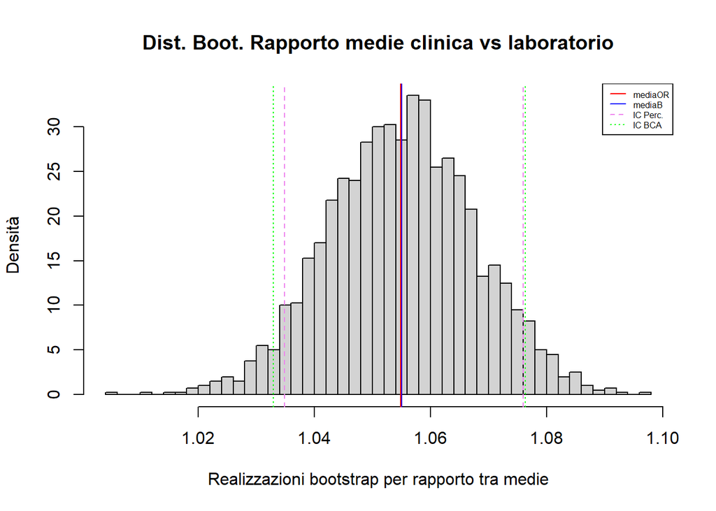

```r
hist(bootw$thetastar,
main = "Dist. Boot. Rapporto medie clinica vs laboratorio",
breaks = 60,
freq = FALSE,
ylab = "Densità",
xlab = "Realizzazioni bootstrap per rapporto tra medie")
abline(v = c(th, Tm1,
Q[1], Q[2],
CIBca[["confpoints"]][3], CIBca[["confpoints"]][4]),
col = c("red", "blue", "violet","violet", "green", "green"),
lty = c(1, 1, 2, 2, 3, 3))
legend("topright",
c("mediaOR", "mediaB", "IC Perc.", "IC BCA"),
col = c("red", "blue", "violet", "green"),
lty = c(1, 1, 2, 3),
cex = 0.5)
```

The graphical representation of the bootstrap distribution shows that the obtained values are distributed approximately symmetrically. The average calculated on the original sample is the average of the bootstrap estimates coincide and are approximately at the central and highest peak of the histogram. The lines of the confidence intervals are very close between them, even if the amplitude of that obtained with the bootstrap method is slightly greater (as noted previously).

## Exercise 29

Consider a randomized study conducted on 139 women who had cancer at the breast. We intend to evaluate the presence of metastases (𝑌 ) in women who have performed an immunotherapy treatment called Tumor-Infiltrating Lymphocytes (𝑋). Consider the following absolute frequencies of the contingency table a double entry $𝑁_{11} = 10, 𝑁_{1.} = 59, 𝑁_{01} = 50, 𝑁_{0.} = 80$.

1. Assuming we are interested in estimating the relative risk of developing metastases, report and comment on the resulting value referring to the rough estimate likelihood.
2. Apply the bootstrap method considering 2000 repetitions and setting the seed to value 2753 and provide a measure of variability for the estimate obtained in the point previous.
3. Plot and comment on the bootstrap distribution of relative risk, together at the extremes of the confidence interval obtained with the percentile method.
4. Draw the distribution of the estimation error and comment on it.
5. Consider the maximum likelihood estimator of the relative difference

$$\hat{D}= \hat{p_1} - \hat{p_0}$$
Determine the estimate in the sample considered and interpret the result obtained. 6. Draw the distribution obtained with the bootstrap method and add the value original and that of bootstrap replications. Comment on the graph. 7. Determine the 95% confidence intervals for the relative risk with the method of the percentile and with the Bca method for the difference in probability estimator. Comment on the results.

29.1

Data referring to the presence of metastases relating to 139 women with breast cancer are analysed compared to immunotherapy treatment. The corresponding dataframe is constructed, denoting with 𝑋 the immunotherapy treatment variable and with 𝑌 the metastasis variable. Relative risk yes calculates as the ratio between the frequency of women with metastases and immunotherapy treatment and the frequency of women with metastases but without immunotherapy treatment.

```r
dataR <- data.frame(X = rep(c("TRUE", "FALSE"), c(59, 80)),
Y = rep(c(TRUE, FALSE, TRUE, FALSE), c(10, 59-10, 50, 80-50)))
table(dataR)
```

```
##        Y
## X       FALSE TRUE
##   FALSE    30   50
##   TRUE     49   10
```

```r
CC <- proportions(table(dataR), 1); CC
```

```
##        Y
## X           FALSE      TRUE
##   FALSE 0.3750000 0.6250000
##   TRUE  0.8305085 0.1694915
```

```r
RR <- CC[4]/CC[3]; RR
```

```
## [1] 0.2711864
```

The maximum likelihood estimate of the relative risk of developing metastases is 0.27, significantly distant from 1. It can be deduced that there is an association between the presence of metastases and the immunotherapy treatment: the probability of having metastases is approximately four times lower for women who have undergone immunotherapy treatment compared to women who have not executed.

29.2

We use the bootstrap method to determine a measure of accuracy for the resulting result to the previous point. The dataset from which to resample is made up of two columns, the variables presence/absence of metastases and immunotherapy treatment. Each row of the dataset contains the information relating to a woman: it is therefore necessary to resample the two columns together. We then proceed by resampling the row index (from 1 to 𝑛) and subsequently obtaining the row corresponding in the dataframe. After determining a bootstrap sample the function is applied theta1 which allows you to calculate the relative risk in a similar way to what was done in the point previous.

```r
n <- dim(dataR)[1]
theta1 <- function(i) {
CC <- prop.table(table(dataR[i, ]), 1)
CC[4]/CC[3]
}
set.seed(2753)
boot_RR <- bootstrap::bootstrap(x = 1:n, nboot = 2000, theta = theta1)
summary(boot_RR$thetastar)
```

```
##    Min. 1st Qu.  Median    Mean 3rd Qu.    Max.
## 0.06623 0.21818 0.27119 0.27561 0.32670 0.57845
```

We briefly comment on the results through the main descriptive statistics (function summary). The range of variation of the 2000 bootstrap replications of the relative risk value it is rather limited, varying from a minimum of 0.07 to a maximum of 0.58. It is therefore about values always lower than 1, a sign that the probability of having metastases is significantly reduced for women who have undergone immunotherapy treatment. On average (mean value equal to 0.28) this reduction is approximately 3 and a half times (1/0.28). The average value is approximately equal to that of the median and that of the relative risk calculated on the original dataset. Finally, to obtain a measure of accuracy for the result determined in the previous point, we calculate the standard deviation of the relative risk values over the 2000 bootstrap replications.

```r
sd(boot_RR$thetastar)
```

```
## [1] 0.08048537
```

The result, equal to 0.08, underlines that the standard error is very limited, a sign of high accuracy of the relative risk value calculated on the original dataset.

29.3

Before graphing the bootstrap distribution, let’s calculate the confidence interval with the percentile method; it is simply a matter of determining the appropriate quantiles of the bootstrap distribution.

```r
Q <- quantile(boot_RR$thetastar, c(0.025, 0.975)); Q
```

```
##      2.5%     97.5%
## 0.1311163 0.4427633
```

The extremes of the bootrstap confidence interval with a significance level of 0.95 are 0.13 and 0.44: in 95% of cases (i.e., considering 95% of the bootstrap replications) the risk value relative lies within this interval. We now represent the bootrstap distribution in the form of a histogram, adding the extrema of the confidence interval determined, in addition to the relative risk value calculated on the dataset original, and to the average value over bootstrap replications.

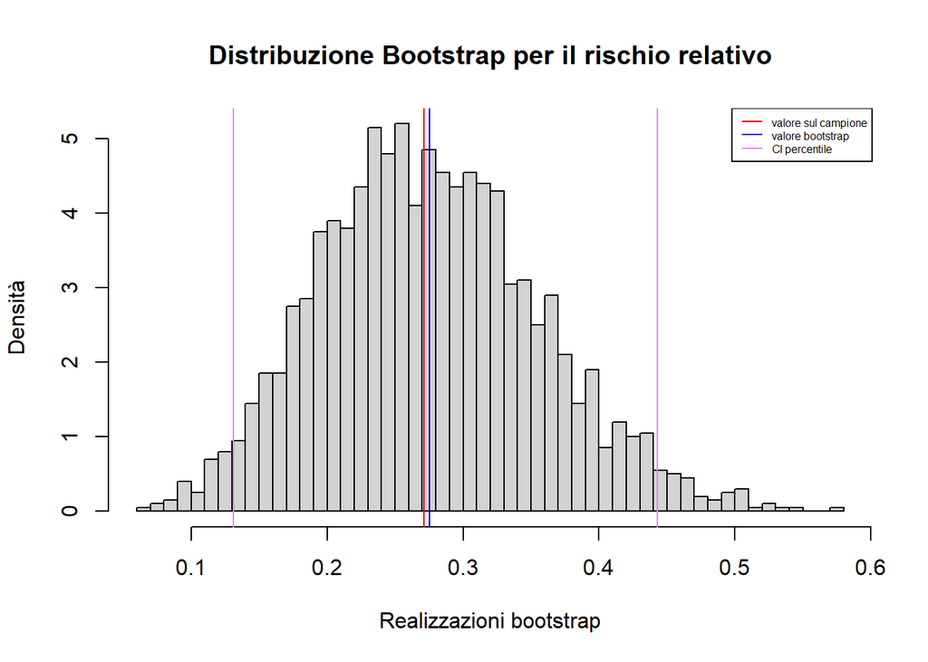

```r
hist(boot_RR$thetastar,
main = "Distribuzione Bootstrap per il rischio relativo",
breaks = 60,
freq = FALSE,
ylab = "Densità",
xlab = "Realizzazioni bootstrap")
abline(v = c(RR, mean(boot_RR$thetastar), Q[1], Q[2]),
col = c("red", "blue", "violet", "violet"))
legend("topright",
c("valore sul campione", "valore bootstrap", "CI percentile"),
col = c("red", "blue", "violet"),
lty= c(1, 1, 1),
cex = 0.5)
```

The shape of the histogram is approximately symmetrical, although slightly right-tailed longer than the left one. The extremes of the confidence interval include the majority of observations (95%), and the values of the relative risk and the average over the replications bootstraps are positioned approximately in the center of the interval. It is also noted that these two values are positioned in the central part of the histogram, although remaining slightly deviated from the highest peak of the bootstrap distribution.

29.4

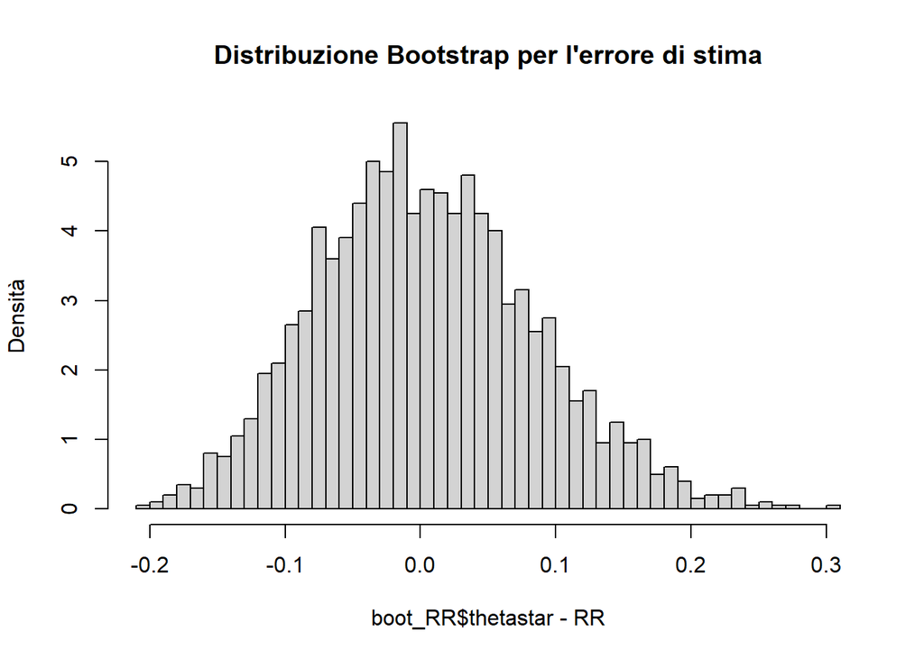

```r
hist(boot_RR$thetastar - RR,
main = "Distribuzione Bootstrap per l'errore di stima",
breaks = 60,
freq = FALSE,
ylab = "Densità")
```

Also in this case the shape of the histogram is approximately symmetrical (obviously follows the shape of the previous histogram). It is observed that the range of variation is quite limited, having a minimum equal to -0.2 and a maximum equal to 0.3. The distribution is centered at 0 (where the highest peak is also located), a sign that on average the estimation error is zero.

29.5

Let us now consider the estimator of the difference between probabilities.

```r
DD <- CC[4]-CC[3]; DD
```

```
## [1] -0.4555085
```

29.6

Similarly to what was done for the relative risk estimator, 2000 replications are obtained bootstrap the dataset and s calculates the difference in probabilities on each of these.

```r
n <- dim(dataR)[1]
theta2 <- function(i) {
CC <- prop.table(table(dataR[i, ]), 1)
DD <- CC[4] - CC[3]
}
set.seed(2753)
boot_DD <- bootstrap::bootstrap(x = 1:n, nboot = 2000, theta = theta2)
summary(boot_DD$thetastar)
```

```
##    Min. 1st Qu.  Median    Mean 3rd Qu.    Max.
## -0.6617 -0.5017 -0.4523 -0.4525 -0.4036 -0.2270
```

```r
sd(boot_DD$thetastar)
```

```
## [1] 0.0709495
```

The values obtained for each of the 2000 bootstrap samples have a range of variation entirely contained in the set of real numbers less than zero; the value of the maximum is equal to - 0.23 (the minimum is instead -0.66), confirming the fact that, for each bootstrap replication, the women who have not undergone immunotherapy treatment are more likely to develop metastasis. On average the difference between the probabilities is equal to -0.45, a value coinciding with both the median and with the difference obtained on the original dataset.

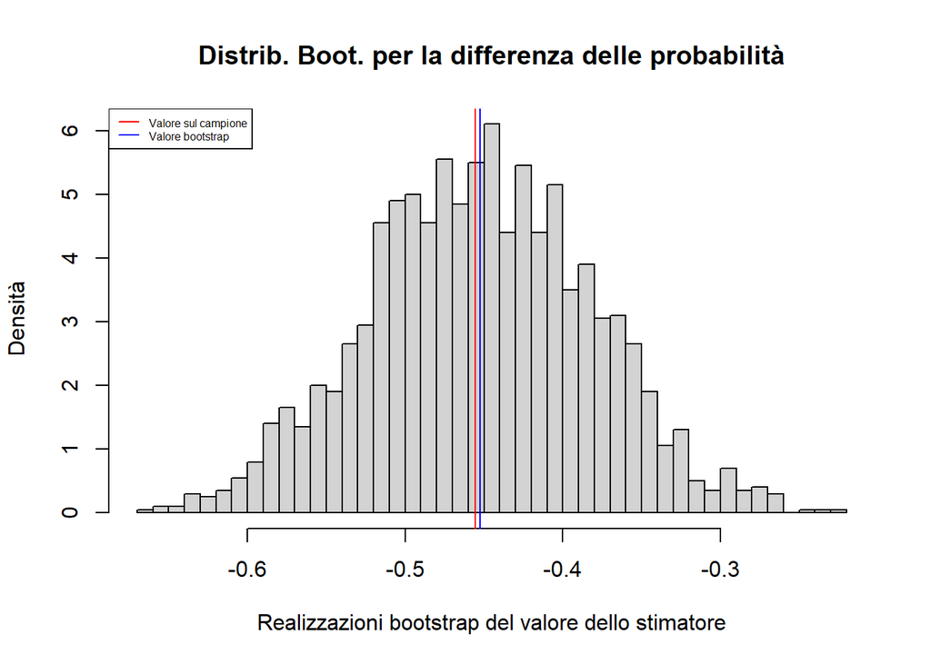

```r
hist(boot_DD$thetastar,
main = "Distrib. Boot. per la differenza delle probabilità",
breaks = 60,
freq = FALSE,
ylab = "Densità",
xlab = "Realizzazioni bootstrap del valore dello stimatore")
abline(v = c(DD, mean(boot_DD$thetastar)),
col = c("red", "blue"))
legend("topleft",c("Valore sul campione", "Valore bootstrap"),
col = c("red", "blue"),
lty= c(1, 1),
cex = 0.5)
```

The graphical representation of the bootstrap distribution confirms the conclusions drawn so far; we also observe that it has an approximately symmetrical shape around a peak central which coincides both with the average of the bootstrap values and with the result obtained on the sample original.

29.7

Finally, we calculate the confidence intervals (95%) for the value of the difference in probabilities using both the percentile method and the BCA method.

```r
quantile(boot_DD$thetastar, c(0.025, 0.975))
```

```
##       2.5%      97.5%
## -0.5898717 -0.3172210
```

```r
boot_DD_CI <- bootstrap::bcanon(x = 1:n,
nboot = 2000,
theta = theta2,
alpha = c(0.025, 0.975))
boot_DD_CI$confpoints
```

```
##      alpha  bca point
## [1,] 0.025 -0.5904762
## [2,] 0.975 -0.3035191
```

The confidence interval obtained with the percentile method is [−0.59, −0.32]; includes only values negative, further confirming the association between the onset of metastases and the (non) execution of immunotherapy treatment. It is interpreted considering that in 95% of cases (95% of the bootstrap samples considered) the value of the difference between the probabilities falls within of the interval. The BCA method allows you to correct for distortion. The resulting interval is very similar to the previous one, but has a slightly wider amplitude. We observe that the two parameters of the latter range, acceleration and correction for distortion, are both different from 0.

```r
boot_DD_CI$acc
```

```
## [1] 0.01549495
```

```r
boot_DD_CI$z0
```

```
## [1] -0.001253314
```

## Exercise 30

Consider the following absolute frequencies assuming a study where two patients with a characteristic of interest were compared with a control group in a specific period of time with respect to three different residential locations (a), (b) and (c). $(a) 𝑁_{11} = 138, 𝑁_{1.} = 3786, 𝑁_{01} = 167, 𝑁_{0.} = 3411, (b) 𝑁_{11} = 186, 𝑁_{1.} = 5775, 𝑁_{01} = 250, 𝑁_{0.} = 5445, (c) 𝑁_{11} = 123, 𝑁_{1.} = 1446, 𝑁_{01} = 117, 𝑁_{0.} = 14294. 1. Report and interpret the estimate obtained with the maximum likelihood method of the relative risk for the three locations. 2. Report and interpret the estimate of the 95% confidence interval obtained with the bootstrap procedure using the percentile method. 3. Report and interpret the histogram of the bootstrap distribution by inserting the estimate of the relative risk in the sample, the average of the replication estimates bootstrap and the extremes of the interval calculated in the previous point for each lease.

4. Can independence be established between 𝑌 and 𝑋 at some location? Justify it answer.
5. determine the 95% confidence intervals with the Bca method for the estimator of relative risk. Comment on the differences with the intervals obtained with the percentile method for each location.